# PaperMelanoma

# Multiple imputation

```r
variables.to.be.imputed <- c("Center", "SNstatus", "Sex", "Age.SN", "Ulceration",
                             "Loc_CAT", "Histology", "Breslow", "multiple.fields",
                             "Tot_SNs_neg", "Tot_SNs_pos", "Rdamcrit", "Dewar",
                             "Mitosis",
                             "Recurrence", "dead", "MSM")
data.to.be.imputed <- sel.data[,variables.to.be.imputed]
```

Save distributions of all variables, necessary for Harrell summaries

```r
dd<-rms::datadist(data.to.be.imputed)
options(datadist='dd')
options(digits=8)
```

Relation between outcome and covariates

```r
data.to.be.imputed$logRec.time <- log(sel.data$Rec.time+1/365.25)
data.to.be.imputed$logFU.time <- log(sel.data$FU.time+1/365.25)
missings.table(data.to.be.imputed)
```

```
##                    m
## Mitosis         3895
## Histology        353
## Dewar            303
## Rdamcrit         301
## Tot_SNs_neg      162
## Ulceration       141
## Loc_CAT          138
## Breslow           59
## logRec.time       45
## Tot_SNs_pos        1
## Center             0
## SNstatus           0
## Sex                0
## Age.SN             0
## multiple.fields    0
## Recurrence         0
## dead               0
## MSM                0
## logFU.time         0
```

```r
save(data.to.be.imputed,file='Z:/Project Melanoom/PaperMelanoma/Data/descr.data.Rdata', compress=TRUE)
```

Number of imputations

```r
m <- 5
```

Perform multiple imputation

```r
imputed.data <- mice::mice(data.to.be.imputed, m=m, maxit=5, print=FALSE, seed=500)
print(imputed.data$loggedEvents)
save(imputed.data,file='Z:/Project Melanoom/PaperMelanoma/Data/imputed.data.RData', compress=TRUE)
```

Load imputed data set

```r
load('Z:/Project Melanoom/PaperMelanoma/Data/imputed.data.RData')
last.imputed.data.set <- mice::complete(imputed.data, m)
summary(last.imputed.data.set)
```

```
##        Center         SNstatus        Sex           Age.SN       Ulceration
##  Rotterdam: 566   Negative:3182   female:2075   Min.   :13.000   No :2858
##  Berlin   :1343   Positive: 889   male  :1996   1st Qu.:43.000   Yes:1213
##  Warsaw   :1179                                 Median :55.000
##  Amsterdam: 983                                 Mean   :54.229
##                                                 3rd Qu.:66.000
##                                                 Max.   :94.000
##         Loc_CAT     Histology       Breslow        multiple.fields
##  arm        : 633   SSM  :2322   Min.   : 0.1000   Min.   :0.000000
##  leg        :1224   NM   :1374   1st Qu.: 1.2000   1st Qu.:0.000000
##  trunk      :1897   ALM  : 143   Median : 2.0000   Median :0.000000
##  head & neck: 317   other: 232   Mean   : 2.8285   Mean   :0.091869
##                                  3rd Qu.: 3.5000   3rd Qu.:0.000000
##                                  Max.   :90.0000   Max.   :1.000000
##   Tot_SNs_neg       Tot_SNs_pos         Rdamcrit               Dewar
##  Min.   : 0.0000   Min.   :0.00000   Min.   : 0.0100   subcap     :3402
##  1st Qu.: 1.0000   1st Qu.:0.00000   1st Qu.: 1.0000   combined   : 322
##  Median : 1.0000   Median :0.00000   Median : 1.0000   parenchymal: 122
##  Mean   : 1.6495   Mean   :0.27364   Mean   : 1.2214   multifocal :  79
##  3rd Qu.: 2.0000   3rd Qu.:0.00000   3rd Qu.: 1.0000   extensive  : 146
##  Max.   :15.0000   Max.   :5.00000   Max.   :38.0000
##  Mitosis            Recurrence    dead           MSM          logRec.time
##  No :1128   no recurrence:3209   No :3465   Min.   :0.0000   Min.   :-5.90058
##  Yes:2943   recurred     : 862   Yes: 606   1st Qu.:0.0000   1st Qu.: 0.31302
##                                             Median :0.0000   Median : 1.24304
##                                             Mean   :0.1238   Mean   : 0.89444
##                                             3rd Qu.:0.0000   3rd Qu.: 1.86689
##                                             Max.   :1.0000   Max.   : 2.88082
##    logFU.time
##  Min.   :-5.90058
##  1st Qu.: 0.64117
##  Median : 1.39854
##  Mean   : 1.07637
##  3rd Qu.: 1.94012
##  Max.   : 2.88205
```

```r
missings.table(last.imputed.data.set)
```

```
##                 m
## Center          0
## SNstatus        0
## Sex             0
## Age.SN          0
## Ulceration      0
## Loc_CAT         0
## Histology       0
## Breslow         0
## multiple.fields 0
## Tot_SNs_neg     0
## Tot_SNs_pos     0
## Rdamcrit        0
## Dewar           0
## Mitosis         0
## Recurrence      0
## dead            0
## MSM             0
## logRec.time     0
## logFU.time      0
```

# Set as survival data

```r
S.Rec <- survival::Surv(exp(last.imputed.data.set$logRec.time), sel.data$Recurrence=="recurred")
S.MSM <- survival::Surv(exp(last.imputed.data.set$logFU.time), sel.data$MSM)
```

### Kaplan-Meier plots

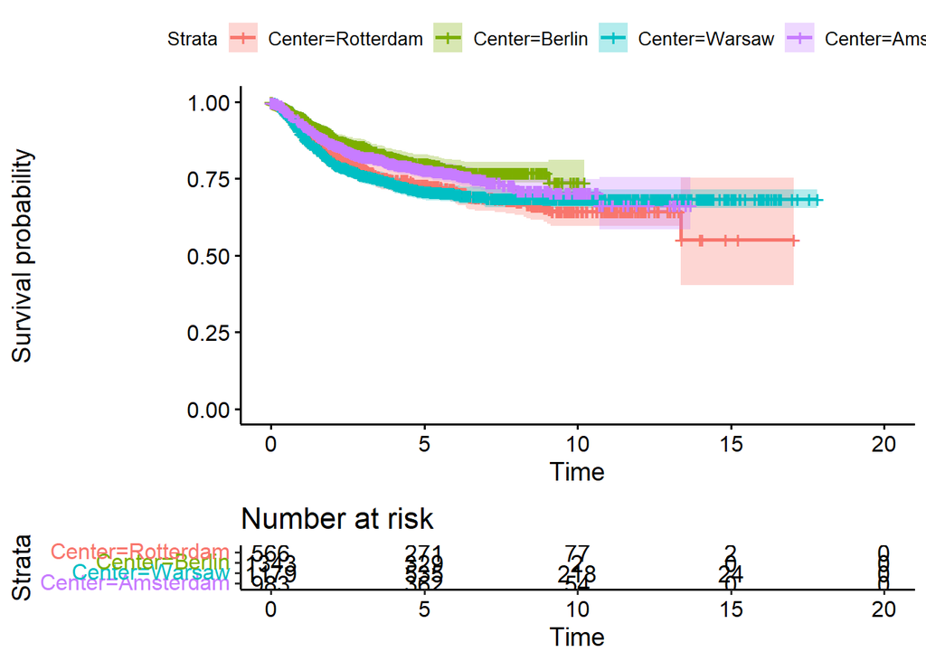

```r
center.Rec.KM <- survival::survfit(S.Rec ~ Center, data=sel.data)
survminer::ggsurvplot(center.Rec.KM, conf.int=TRUE, risk.table=TRUE)
```

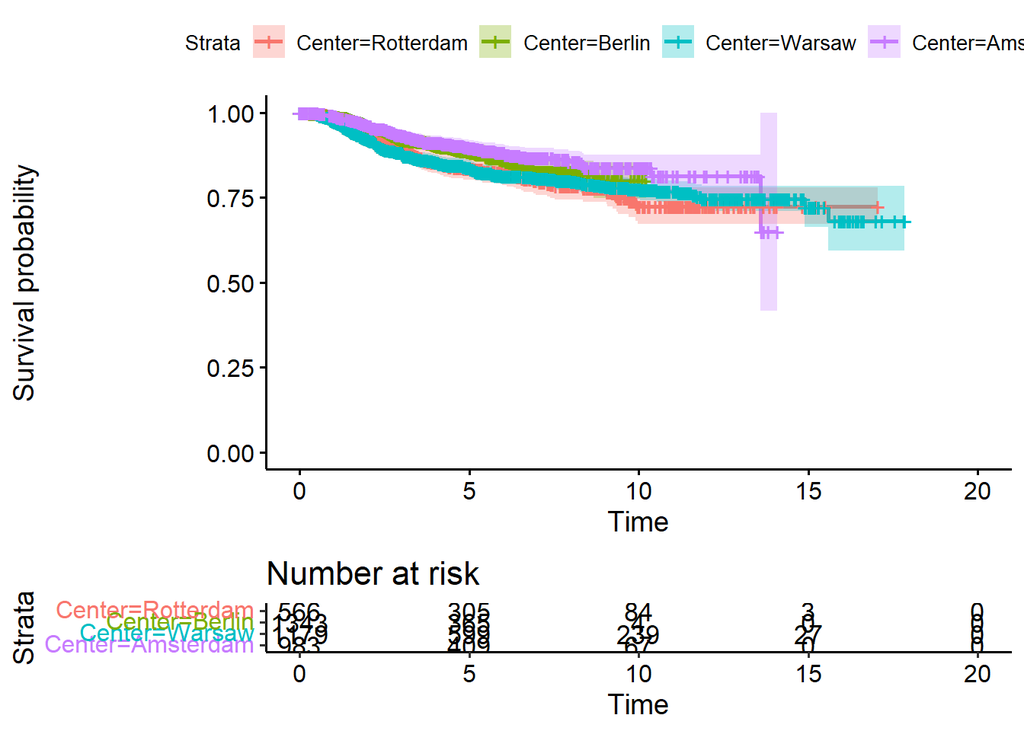

```r
center.MSM.KM <- survival::survfit(S.MSM ~ Center, data=sel.data)
survminer::ggsurvplot(center.MSM.KM, conf.int=TRUE, risk.table=TRUE)
```

# Median follow-up time

```r
median.FU.time.total <- stats::quantile(prodlim::prodlim(prodlim::Hist(exp(logFU.time), MSM)~1, data=last.imputed.data.set, reverse=TRUE))
tab.FU.time <- c("total", paste(sprintf("%.2f", median.FU.time.total$quantiles.survival[3, "quantile"]),
                 paste0("[", sprintf("%.2f", median.FU.time.total$quantiles.survival[3, "lower"]), "; ",
                        sprintf("%.2f", median.FU.time.total$quantiles.survival[3, "upper"]), "]")))
median.FU.time <- stats::quantile(prodlim::prodlim(prodlim::Hist(exp(logFU.time), MSM)~Center, data=last.imputed.data.set, reverse=TRUE))
for (center in sort(as.character(unique(sel.data$Center)))){
  med.FU.table <- eval(parse(text=paste0("median.FU.time$`Center=", center, "`")))
  med.FU <- med.FU.table[3,"quantile"]
  lower.FU <- med.FU.table[3,"lower"]
  upper.FU <- med.FU.table[3,"upper"]
  tab.FU.time <- rbind(tab.FU.time, c(center, paste(sprintf("%.2f", med.FU), paste0("[", sprintf("%.2f", lower.FU), "; ", sprintf("%.2f", upper.FU), "]"))))
}
write.table(as.data.frame(tab.FU.time),file='Z:/Project Melanoom/PaperMelanoma/Results/med.FU.table.txt',
            row.names=FALSE, sep=",")
tab.FU.time
```

```
##             [,1]        [,2]
## tab.FU.time "total"     "4.79 [4.60; 4.94]"
##             "Amsterdam" "4.75 [4.48; 4.98]"
##             "Berlin"    "2.73 [2.46; 3.03]"
##             "Rotterdam" "6.33 [6.06; 7.07]"
##             "Warsaw"    "6.19 [5.91; 6.73]"
```

# Recurrence at 5 years

```r
horizon <- 5
SF.Rec.all<-survfit(S.Rec~1)
Rec.all <- 100*(1-SF.Rec.all$surv[SF.Rec.all$time==max(SF.Rec.all$time[SF.Rec.all$time<=horizon])])

SF.Rec.neg<-survfit(S.Rec[sel.data$SNstatus=="Negative"]~1)
Rec.neg <- 100*(1-SF.Rec.neg$surv[SF.Rec.neg$time==max(SF.Rec.neg$time[SF.Rec.neg$time<=horizon])])

SF.Rec.pos<-survfit(S.Rec[sel.data$SNstatus=="Positive"]~1)
Rec.pos <- 100*(1-SF.Rec.pos$surv[SF.Rec.pos$time==max(SF.Rec.pos$time[SF.Rec.pos$time<=horizon])])

SF.MSM.all<-survfit(S.MSM~1)
MSM.all <- 100*(1-SF.MSM.all$surv[SF.MSM.all$time==max(SF.MSM.all$time[SF.MSM.all$time<=horizon])])

SF.MSM.neg<-survfit(S.MSM[sel.data$SNstatus=="Negative"]~1)
MSM.neg <- 100*(1-SF.MSM.neg$surv[SF.MSM.neg$time==max(SF.MSM.neg$time[SF.MSM.neg$time<=horizon])])

SF.MSM.pos<-survfit(S.MSM[sel.data$SNstatus=="Positive"]~1)
MSM.pos <- 100*(1-SF.MSM.pos$surv[SF.MSM.pos$time==max(SF.MSM.pos$time[SF.MSM.pos$time<=horizon])])

Rec.MSM.table <- data.frame(n=c(nrow(sel.data),
                                sum(sel.data$SNstatus=="Negative"),
                                sum(sel.data$SNstatus=="Positive")),
                            perc=c(100,
                                   sprintf("%.1f", sum(sel.data$SNstatus=="Negative")/nrow(sel.data)*100),
                                   sprintf("%.1f", sum(sel.data$SNstatus=="Positive")/nrow(sel.data)*100)),
                            Rec=sprintf("%.1f", c(Rec.all, Rec.neg, Rec.pos)),
                            MSM=sprintf("%.1f", c(MSM.all, MSM.neg, MSM.pos)))
row.names(Rec.MSM.table) <- c("All", "Negative", "Positive")
utils::write.table(as.data.frame(Rec.MSM.table),file='Z:/Project Melanoom/PaperMelanoma/Results/Rec.MSM.table.txt',
                   row.names=TRUE, sep=",")
Rec.MSM.table
```

```
##             n perc  Rec  MSM
## All      4071  100 24.5 13.5
## Negative 3182 78.2 18.0  8.9
## Positive  889 21.8 48.7 30.9
```

# Restrict survival at 5 years

```r
S.Rec.5 <- S.Rec
S.Rec.5[S.Rec[,1]>5, 1] <- 5 # set recurrence time to 5
S.Rec.5[S.Rec[,1]>5, 2] <- 0 # set censoring

S.MSM.5 <- S.MSM
S.MSM.5[S.MSM[,1]>5, 1] <- 5 # set follow-up time to 5
S.MSM.5[S.MSM[,1]>5, 2] <- 0 # set censoring
```

# Obtain C-index of AJCC7 and AJCC8

```r
TNM.7 <- c()
AJCC.7 <- c()
cindex.AJCC.7 <- rep(0, m)
cindex.AJCC.7.se <- rep(0, m)
cindex.AJCC.7.pos <- rep(0, m)
cindex.AJCC.7.se.pos <- rep(0, m)
cindex.AJCC.7.neg <- rep(0, m)
cindex.AJCC.7.se.neg <- rep(0, m)
for (i in 1:m){
  imputation.i <- mice::complete(imputed.data,i)
  TNM.7.i <- rep("", nrow(imputation.i))
  AJCC.7.i <- rep(0, nrow(imputation.i))
  for (patient in 1:nrow(imputation.i)){
    breslow.patient <- imputation.i[patient, "Breslow"]
    ulceration.patient <- as.character(imputation.i[patient, "Ulceration"])
    mitosis.patient <- as.character(imputation.i[patient, "Mitosis"])
    nodes.patient <- imputation.i[patient, "Tot_SNs_pos"]

    snstatus.patient <- imputation.i[patient, "SNstatus"]

    # T stage
    if (breslow.patient <= 1){
      if (ulceration.patient=="No" & mitosis.patient=="No"){
        TNM.7.i[patient] <- paste0(TNM.7.i[patient], "T1a")
      } else if (ulceration.patient=="Yes" | mitosis.patient=="Yes"){
        TNM.7.i[patient] <- paste0(TNM.7.i[patient], "T1b")
      }
    } else if (breslow.patient>1 & breslow.patient <= 2){
      if (ulceration.patient=="No"){
        TNM.7.i[patient] <- paste0(TNM.7.i[patient], "T2a")
      } else if (ulceration.patient=="Yes"){
        TNM.7.i[patient] <- paste0(TNM.7.i[patient], "T2b")
      }
    } else if (breslow.patient>2 & breslow.patient <= 4){
      if (ulceration.patient=="No"){
        TNM.7.i[patient] <- paste0(TNM.7.i[patient], "T3a")
      } else if (ulceration.patient=="Yes"){
        TNM.7.i[patient] <- paste0(TNM.7.i[patient], "T3b")
      }
    } else if (breslow.patient>4){
      if (ulceration.patient=="No"){
        TNM.7.i[patient] <- paste0(TNM.7.i[patient], "T4a")
      } else if (ulceration.patient=="Yes"){
        TNM.7.i[patient] <- paste0(TNM.7.i[patient], "T4b")
      }
    }

    # N stage
    if (nodes.patient == 0){
      TNM.7.i[patient] <- paste0(TNM.7.i[patient], "N0")
    } else if (nodes.patient==1){
      TNM.7.i[patient] <- paste0(TNM.7.i[patient], "N1a")
    } else if (nodes.patient==2 | nodes.patient==3){
      TNM.7.i[patient] <- paste0(TNM.7.i[patient], "N2a")
    } else if (nodes.patient>3){
      TNM.7.i[patient] <- paste0(TNM.7.i[patient], "N3a")
    }

    # M stage for all patients in our data set
    TNM.7.i[patient] <- paste0(TNM.7.i[patient], "M0")

    # determine AJCC.7.i
    if (TNM.7.i[patient]=="T1aN0M0"){
      AJCC.7.i[patient] <- 1.1
    } else if (TNM.7.i[patient]=="T1bN0M0" | TNM.7.i[patient]=="T2aN0M0"){
      AJCC.7.i[patient] <- 1.2
    } else if (TNM.7.i[patient]=="T2bN0M0" | TNM.7.i[patient]=="T3aN0M0"){
      AJCC.7.i[patient] <- 2.1
    } else if (TNM.7.i[patient]=="T3bN0M0" | TNM.7.i[patient]=="T4aN0M0"){
      AJCC.7.i[patient] <- 2.2
    } else if (TNM.7.i[patient]=="T4bN0M0"){
      AJCC.7.i[patient] <- 2.3
    } else if (TNM.7.i[patient]=="T1aN1aM0" | TNM.7.i[patient]=="T2aN1aM0" | # N1a
               TNM.7.i[patient]=="T3aN1aM0" | TNM.7.i[patient]=="T4aN1aM0" |
               TNM.7.i[patient]=="T1aN2aM0" | TNM.7.i[patient]=="T2aN2aM0" | # N2a
               TNM.7.i[patient]=="T3aN2aM0" | TNM.7.i[patient]=="T4aN2aM0"){
      AJCC.7.i[patient] <- 3.1
    } else if (TNM.7.i[patient]=="T1bN1aM0" | TNM.7.i[patient]=="T2bN1aM0" | # N1a
               TNM.7.i[patient]=="T3bN1aM0" | TNM.7.i[patient]=="T4bN1aM0" |
               TNM.7.i[patient]=="T1bN2aM0" | TNM.7.i[patient]=="T2bN2aM0" | # N2a
               TNM.7.i[patient]=="T3bN2aM0" | TNM.7.i[patient]=="T4bN2aM0" |
               TNM.7.i[patient]=="T1aN1bM0" | TNM.7.i[patient]=="T2aN1bM0" | # N1b
               TNM.7.i[patient]=="T3aN1bM0" | TNM.7.i[patient]=="T4aN1bM0" |
               TNM.7.i[patient]=="T1aN2bM0" | TNM.7.i[patient]=="T2aN2bM0" | # N2b
               TNM.7.i[patient]=="T3aN2bM0" | TNM.7.i[patient]=="T4aN2bM0" |
               TNM.7.i[patient]=="T1aN2cM0" | TNM.7.i[patient]=="T2aN2cM0" | # N2c
               TNM.7.i[patient]=="T3aN2cM0" | TNM.7.i[patient]=="T4aN2cM0"){
      AJCC.7.i[patient] <- 3.2
    } else {
      AJCC.7.i[patient] <- 3.3
    }
  }

  # save TNM.7 and AJCC.7 for each imputated data set
  TNM.7 <- cbind(TNM.7, TNM.7.i)
  AJCC.7 <- cbind(AJCC.7, AJCC.7.i)

  # compute C-index
  rc <- Hmisc::rcorr.cens(-AJCC.7.i, S.Rec.5) # add a minus to revert class order: from worst to best
  cindex.AJCC.7[i]<-rc["C Index"]
  cindex.AJCC.7.se[i]<-rc["S.D."]/2

  # compute C-index for only positive sentinel node patients
  rc.pos <- Hmisc::rcorr.cens(-AJCC.7.i[imputation.i$SNstatus=="Positive"], S.Rec.5[imputation.i$SNstatus=="Positive",])
  cindex.AJCC.7.pos[i]<-rc.pos["C Index"]
  cindex.AJCC.7.se.pos[i]<-rc.pos["S.D."]/2

  # compute C-index for only negative sentinel node patients
  rc.neg <- Hmisc::rcorr.cens(-AJCC.7.i[imputation.i$SNstatus=="Negative"], S.Rec.5[imputation.i$SNstatus=="Negative",])
  cindex.AJCC.7.neg[i]<-rc.neg["C Index"]
  cindex.AJCC.7.se.neg[i]<-rc.neg["S.D."]/2
}
# combine C-index for each imputed data set
cindex.mi.AJCC.7<-Rubin.combine(cindex.AJCC.7,cindex.AJCC.7.se)
cindex.mi.AJCC.7.pos<-Rubin.combine(cindex.AJCC.7.pos,cindex.AJCC.7.se.pos)
cindex.mi.AJCC.7.neg<-Rubin.combine(cindex.AJCC.7.neg,cindex.AJCC.7.se.neg)

# save C-index and confidence interval
utils::write.table(rbind(c("All patients:", sprintf('%.2f', cindex.mi.AJCC.7$est),
              paste0("[", sprintf('%.2f', cindex.mi.AJCC.7$est+qnorm(.025)*cindex.mi.AJCC.7$se),
                      "; ", sprintf('%.2f', cindex.mi.AJCC.7$est+qnorm(.975)*cindex.mi.AJCC.7$se), "]")),
            c("Positive SN patients:", sprintf('%.2f', cindex.mi.AJCC.7.pos$est),
                  paste0("[", sprintf('%.2f', cindex.mi.AJCC.7.pos$est+qnorm(.025)*cindex.mi.AJCC.7.pos$se),
                         "; ", sprintf('%.2f', cindex.mi.AJCC.7.pos$est+qnorm(.975)*cindex.mi.AJCC.7.pos$se), "]")),
            c("Negative SN patients:", sprintf('%.2f', cindex.mi.AJCC.7.neg$est),
                  paste0("[", sprintf('%.2f', cindex.mi.AJCC.7.neg$est+qnorm(.025)*cindex.mi.AJCC.7.neg$se),
                         "; ", sprintf('%.2f', cindex.mi.AJCC.7.neg$est+qnorm(.975)*cindex.mi.AJCC.7.neg$se), "]"))),
            file='Z:/Project Melanoom/PaperMelanoma/Results/AJCC.7.Cindex.txt',
            row.names=FALSE, col.names=FALSE, sep=",")
```

```r
#####
##### COMPARE MODEL WITH AJCC.8 CLASIFCATION
#####
TNM.8 <- c()
AJCC.8 <- c()
cindex.AJCC.8 <- rep(0, m)
cindex.AJCC.8.se <- rep(0, m)
cindex.AJCC.8.pos <- rep(0, m)
cindex.AJCC.8.se.pos <- rep(0, m)
cindex.AJCC.8.neg <- rep(0, m)
cindex.AJCC.8.se.neg <- rep(0, m)
for (i in 1:m){
  imputation.i <- mice::complete(imputed.data,i)
  TNM.8.i <- rep("", nrow(imputation.i))
  AJCC.8.i <- rep(0, nrow(imputation.i))
  for (patient in 1:nrow(imputation.i)){
    breslow.patient <- imputation.i[patient, "Breslow"]
    ulceration.patient <- as.character(imputation.i[patient, "Ulceration"])
    mitosis.patient <- as.character(imputation.i[patient, "Mitosis"])
    nodes.patient <- imputation.i[patient, "Tot_SNs_pos"]

    # T stage
    if (breslow.patient <= 1){
      if (ulceration.patient=="No" & breslow.patient < 0.8){
        TNM.8.i[patient] <- paste0(TNM.8.i[patient], "T1a")
      } else {
        TNM.8.i[patient] <- paste0(TNM.8.i[patient], "T1b")
      }
    } else if (breslow.patient>1 & breslow.patient <= 2){
      if (ulceration.patient=="No"){
        TNM.8.i[patient] <- paste0(TNM.8.i[patient], "T2a")
      } else if (ulceration.patient=="Yes"){
        TNM.8.i[patient] <- paste0(TNM.8.i[patient], "T2b")
      }
    } else if (breslow.patient>2 & breslow.patient <= 4){
      if (ulceration.patient=="No"){
        TNM.8.i[patient] <- paste0(TNM.8.i[patient], "T3a")
      } else if (ulceration.patient=="Yes"){
        TNM.8.i[patient] <- paste0(TNM.8.i[patient], "T3b")
      }
    } else if (breslow.patient>4){
      if (ulceration.patient=="No"){
        TNM.8.i[patient] <- paste0(TNM.8.i[patient], "T4a")
      } else if (ulceration.patient=="Yes"){
        TNM.8.i[patient] <- paste0(TNM.8.i[patient], "T4b")
      }
    }

    # N stage
    if (nodes.patient == 0){
      TNM.8.i[patient] <- paste0(TNM.8.i[patient], "N0")
    } else if (nodes.patient==1){
      TNM.8.i[patient] <- paste0(TNM.8.i[patient], "N1a")
    } else if (nodes.patient==2 | nodes.patient==3){
      TNM.8.i[patient] <- paste0(TNM.8.i[patient], "N2a")
    } else if (nodes.patient>3){
      TNM.8.i[patient] <- paste0(TNM.8.i[patient], "N3a")
    }

    # M stage for all patients in our data set
    TNM.8.i[patient] <- paste0(TNM.8.i[patient], "M0")

    # determine AJCC.8.i
    if (TNM.8.i[patient]=="T1aN0M0"){
      AJCC.8.i[patient] <- 1.1
    } else if (TNM.8.i[patient]=="T1bN0M0" | TNM.8.i[patient]=="T2aN0M0"){
      AJCC.8.i[patient] <- 1.2
    } else if (TNM.8.i[patient]=="T2bN0M0" | TNM.8.i[patient]=="T3aN0M0"){
      AJCC.8.i[patient] <- 2.1
    } else if (TNM.8.i[patient]=="T3bN0M0" | TNM.8.i[patient]=="T4aN0M0"){
      AJCC.8.i[patient] <- 2.2
    } else if (TNM.8.i[patient]=="T4bN0M0"){
      AJCC.8.i[patient] <- 2.3
    } else if (TNM.8.i[patient]=="T1aN1aM0" | TNM.8.i[patient]=="T1bN1aM0" | TNM.8.i[patient]=="T2aN1aM0"
               | TNM.8.i[patient]=="T1aN2aM0" | TNM.8.i[patient]=="T1bN2aM0" | TNM.8.i[patient]=="T2aN2aM0"){
      AJCC.8.i[patient] <- 3.1
    } else if (TNM.8.i[patient]=="T2bN1aM0" | TNM.8.i[patient]=="T3aN1aM0"){
      AJCC.8.i[patient] <- 3.2
    } else if (TNM.8.i[patient]=="T4bN3aM0"){
      AJCC.8.i[patient] <- 3.4
    } else {
      AJCC.8.i[patient] <- 3.3
    }

  }

  # save TNM.8 and AJCC.8 for each imputated data set
  TNM.8 <- cbind(TNM.8, TNM.8.i)
  AJCC.8 <- cbind(AJCC.8, AJCC.8.i)

  # compute C-index
  rc <- Hmisc::rcorr.cens(-AJCC.8.i, S.Rec.5) # add a minus to revert class order: from worst to best
  cindex.AJCC.8[i]<-rc["C Index"]
  cindex.AJCC.8.se[i]<-rc["S.D."]/2

  # compute C-index for only positive sentinel node patients
  rc.pos <- Hmisc::rcorr.cens(-AJCC.8.i[imputation.i$SNstatus=="Positive"], S.Rec.5[imputation.i$SNstatus=="Positive",])
  cindex.AJCC.8.pos[i]<-rc.pos["C Index"]
  cindex.AJCC.8.se.pos[i]<-rc.pos["S.D."]/2

  # compute C-index for only negative sentinel node patients
  rc.neg <- Hmisc::rcorr.cens(-AJCC.8.i[imputation.i$SNstatus=="Negative"], S.Rec.5[imputation.i$SNstatus=="Negative",])
  cindex.AJCC.8.neg[i]<-rc.neg["C Index"]
  cindex.AJCC.8.se.neg[i]<-rc.neg["S.D."]/2
}
# combine C-index for each imputed data set
cindex.mi.AJCC.8<-Rubin.combine(cindex.AJCC.8,cindex.AJCC.8.se)
cindex.mi.AJCC.8.pos<-Rubin.combine(cindex.AJCC.8.pos,cindex.AJCC.8.se.pos)
cindex.mi.AJCC.8.neg<-Rubin.combine(cindex.AJCC.8.neg,cindex.AJCC.8.se.neg)

# save C-index and confidence interval
utils::write.table(rbind(c("All patients:", sprintf('%.2f', cindex.mi.AJCC.8$est),
                        paste0("[", sprintf('%.2f', cindex.mi.AJCC.8$est+qnorm(.025)*cindex.mi.AJCC.8$se),
                               "; ", sprintf('%.2f', cindex.mi.AJCC.8$est+qnorm(.975)*cindex.mi.AJCC.8$se), "]")),
                  c("Positive SN patients:", sprintf('%.2f', cindex.mi.AJCC.8.pos$est),
                        paste0("[", sprintf('%.2f', cindex.mi.AJCC.8.pos$est+qnorm(.025)*cindex.mi.AJCC.8.pos$se),
                               "; ", sprintf('%.2f', cindex.mi.AJCC.8.pos$est+qnorm(.975)*cindex.mi.AJCC.8.pos$se), "]")),
                  c("Negative SN patients", sprintf('%.2f', cindex.mi.AJCC.8.neg$est),
                        paste0("[", sprintf('%.2f', cindex.mi.AJCC.8.neg$est+qnorm(.025)*cindex.mi.AJCC.8.neg$se),
                               "; ", sprintf('%.2f', cindex.mi.AJCC.8.neg$est+qnorm(.975)*cindex.mi.AJCC.8.neg$se), "]"))),
            file='Z:/Project Melanoom/PaperMelanoma/Results/AJCC.8.Cindex.txt',
            row.names=FALSE, col.names=FALSE, sep=",")

# table of number of AJCC.7 and AJCC.8
table.AJCC.7 <- c()
table.AJCC.8 <- c()
for (i in 1:m){
  table.AJCC.7 <- cbind(table.AJCC.7, as.numeric(table(AJCC.7[,i])))
  table.AJCC.8 <- cbind(table.AJCC.8, as.numeric(table(AJCC.8[,i])))
}
table.AJCC.7.8 <- cbind(as.numeric(names(table(AJCC.8[,1]))),
                        c(round(rowMeans(table.AJCC.7), 0), 0),
                        round(rowMeans(table.AJCC.8), 0))
utils::write.table(table.AJCC.7.8,
            file='Z:/Project Melanoom/PaperMelanoma/Results/table.AJCC.7.and.8.txt',
            row.names=FALSE, col.names=FALSE, sep=",")
table.AJCC.7.8
```

```
##       [,1] [,2] [,3]
##  [1,]  1.1  217  253
##  [2,]  1.2 1532 1496
##  [3,]  2.1  692  692
##  [4,]  2.2  495  495
##  [5,]  2.3  250  250
##  [6,]  3.1  471  199
##  [7,]  3.2  407  208
##  [8,]  3.3    8  476
##  [9,]  3.4    0    4
```

# Test non-lineairities

### Test if Age should be modelled non-linearly

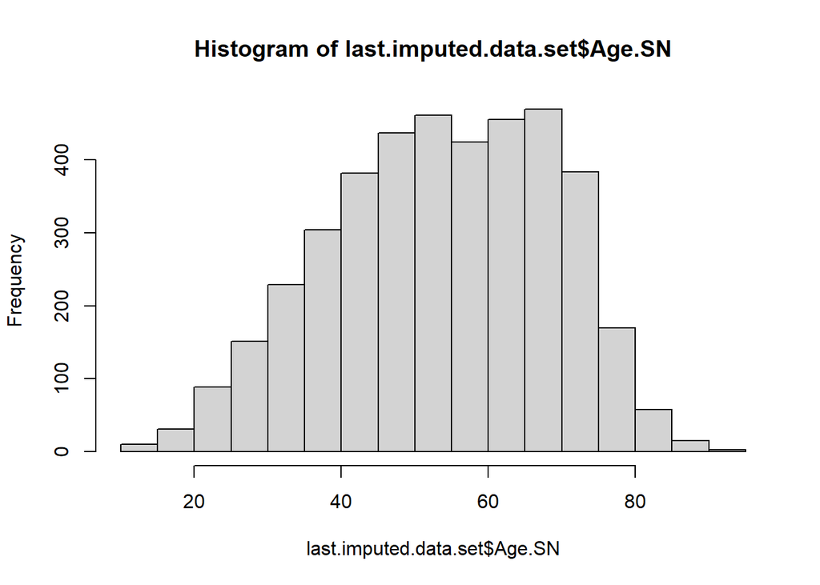

```r
form.linear.full.Rec <- S.Rec.5 ~
  SNstatus +
  Sex +
  Age.SN +
  Ulceration +
  Loc_CAT +
  Histology +
  Breslow +
  multiple.fields +
  Tot_SNs_neg +
  Tot_SNs_pos +
  Rdamcrit +
  Dewar +
  SNstatus:Sex +
  SNstatus:Age.SN +
  SNstatus:Ulceration +
  SNstatus:Loc_CAT +
  SNstatus:Histology +
  SNstatus:Breslow +
  SNstatus:multiple.fields
form.nonlinear.age.full.Rec <- S.Rec.5 ~
  SNstatus +
  Sex +
  rcs(Age.SN) +
  Ulceration +
  Loc_CAT +
  Histology +
  Breslow +
  multiple.fields +
  Tot_SNs_neg +
  Tot_SNs_pos +
  Rdamcrit +
  Dewar +
  SNstatus:Sex +
  SNstatus:rcs(Age.SN) +
  SNstatus:Ulceration +
  SNstatus:Loc_CAT +
  SNstatus:Histology +
  SNstatus:Breslow +
  SNstatus:multiple.fields
linear.full.Rec <- Hmisc::fit.mult.impute(form.linear.full.Rec, cph, xtrans=imputed.data,
                                 data=data.to.be.imputed,n.impute=m, pr=FALSE,
                                 fit.reps=TRUE, y=TRUE, x=TRUE, se.fit=TRUE)
nonlinear.age.full.Rec <- Hmisc::fit.mult.impute(form.nonlinear.age.full.Rec, cph, xtrans=imputed.data,
                                 data=data.to.be.imputed,n.impute=m, pr=FALSE,
                                 fit.reps=TRUE, y=TRUE, x=TRUE, se.fit=TRUE)
# distribution of Age
hist(last.imputed.data.set$Age.SN)
```

```r
# linear model
linear.full.Rec$loglik[2]
```

```
## [1] -5984.5707
```

```r
# using log(Age) gives slightly better log likelihood
nonlinear.age.full.Rec$loglik[2]
```

```
## [1] -5983.1107
```

### Test if Breslow should be modelled non-linearly

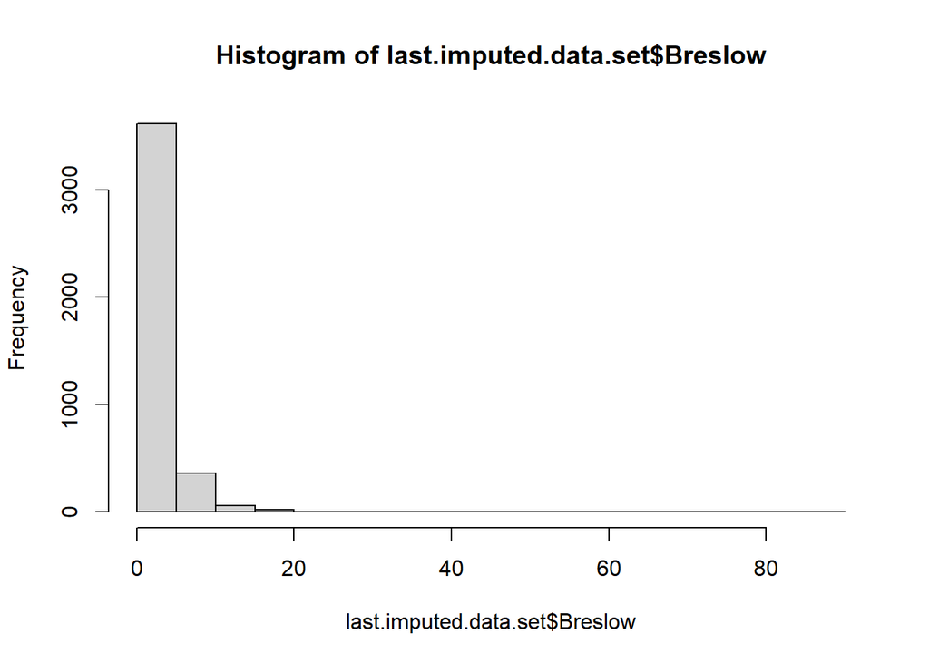

```r
form.nonlinear.Breslow.full.Rec <- S.Rec.5 ~
  SNstatus +
  Sex +
  Age.SN +
  Ulceration +
  Loc_CAT +
  Histology +
  rcs(Breslow) +
  multiple.fields +
  Tot_SNs_neg +
  Tot_SNs_pos +
  Rdamcrit +
  Dewar +
  SNstatus:Sex +
  SNstatus:Age.SN +
  SNstatus:Ulceration +
  SNstatus:Loc_CAT +
  SNstatus:Histology +
  SNstatus:rcs(Breslow) +
  SNstatus:multiple.fields
nonlinear.Breslow.full.Rec <- Hmisc::fit.mult.impute(form.nonlinear.Breslow.full.Rec, cph, xtrans=imputed.data,
                                 data=data.to.be.imputed,n.impute=m, pr=FALSE,
                                 fit.reps=TRUE, y=TRUE, x=TRUE, se.fit=TRUE)
# distribution of Breslow
hist(last.imputed.data.set$Breslow)
```

```r
# linear model
linear.full.Rec$loglik[2]
```

```
## [1] -5984.5707
```

```r
# using log(Breslow) gives better log likelihood
nonlinear.Breslow.full.Rec$loglik[2]
```

```
## [1] -5936.9657
```

```r
# test
anova(nonlinear.Breslow.full.Rec)
```

```
##                 Wald Statistics          Response: S.Rec.5
##
##  Factor                                                    Chi-Square d.f.
##  SNstatus  (Factor+Higher Order Factors)                    32.95     15
##   All Interactions                                          21.63     14
##  Sex  (Factor+Higher Order Factors)                          4.92      2
##   All Interactions                                           1.98      1
##  Age.SN  (Factor+Higher Order Factors)                       9.71      2
##   All Interactions                                           1.29      1
##  Ulceration  (Factor+Higher Order Factors)                  26.76      2
##   All Interactions                                           1.13      1
##  Loc_CAT  (Factor+Higher Order Factors)                     19.49      6
##   All Interactions                                           1.20      3
##  Histology  (Factor+Higher Order Factors)                    8.68      6
##   All Interactions                                           0.05      3
##  Breslow  (Factor+Higher Order Factors)                    142.84      8
##   All Interactions                                          11.09      4
##   Nonlinear (Factor+Higher Order Factors)                   80.68      6
##  multiple.fields  (Factor+Higher Order Factors)              9.51      2
##   All Interactions                                           0.03      1
##  Tot_SNs_neg                                                 2.03      1
##  Tot_SNs_pos                                                 0.06      1
##  Rdamcrit                                                    1.68      1
##  Dewar                                                      12.08      4
##  SNstatus * Sex  (Factor+Higher Order Factors)               1.98      1
##  SNstatus * Age.SN  (Factor+Higher Order Factors)            1.29      1
##  SNstatus * Ulceration  (Factor+Higher Order Factors)        1.13      1
##  SNstatus * Loc_CAT  (Factor+Higher Order Factors)           1.20      3
##  SNstatus * Histology  (Factor+Higher Order Factors)         0.05      3
##  SNstatus * Breslow  (Factor+Higher Order Factors)          11.09      4
##   Nonlinear                                                 10.28      3
##   Nonlinear Interaction : f(A,B) vs. AB                     10.28      3
##  SNstatus * multiple.fields  (Factor+Higher Order Factors)   0.03      1
##  TOTAL NONLINEAR                                            80.68      6
##  TOTAL INTERACTION                                          21.63     14
##  TOTAL NONLINEAR + INTERACTION                              96.20     17
##  TOTAL                                                     671.24     36
##  P
##  0.0048
##  0.0866
```

[output cut: 17 more lines]

```
##  0.1945
##  0.0168
##  0.1598
##  0.2552
##  0.2878
##  0.7534
##  0.9968
##  0.0256
##  0.0163
##  0.0163
##  0.8607
##  <.0001
##  0.0866
##  <.0001
##  <.0001
```

### Test if Rdamcrit should be modelled non-linearly

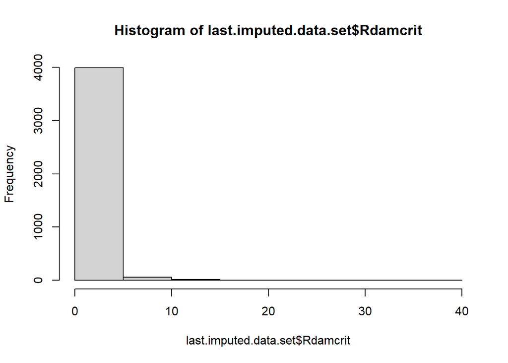

```r
form.nonlinear.Rdamcrit.full.Rec <- S.Rec.5 ~
  SNstatus +
  Sex +
  Age.SN +
  Ulceration +
  Loc_CAT +
  Histology +
  Breslow +
  multiple.fields +
  Tot_SNs_neg +
  Tot_SNs_pos +
  rcs(Rdamcrit) +
  Dewar +
  SNstatus:Sex +
  SNstatus:Age.SN +
  SNstatus:Ulceration +
  SNstatus:Loc_CAT +
  SNstatus:Histology +
  SNstatus:Breslow +
  SNstatus:multiple.fields
nonlinear.Rdamcrit.full.Rec <- Hmisc::fit.mult.impute(form.nonlinear.Rdamcrit.full.Rec, cph, xtrans=imputed.data,
                                 data=data.to.be.imputed,n.impute=m, pr=FALSE,
                                 fit.reps=TRUE, y=TRUE, x=TRUE, se.fit=TRUE)
# distribution of Rdamcrit
hist(last.imputed.data.set$Rdamcrit)
```

```r
# linear model
linear.full.Rec$loglik[2]
```

```
## [1] -5984.5707
```

```r
# using log(Rdamcrit) gives better log likelihood
nonlinear.Rdamcrit.full.Rec$loglik[2]
```

```
## [1] -5981.3476
```

# Full model for recurrence

```r
form.full.Rec.5 <- S.Rec.5 ~
  SNstatus +
  Sex +
  Age.SN +
  Ulceration +
  Loc_CAT +
  Histology +
  log(Breslow) +
  multiple.fields +
  Tot_SNs_neg +
  Tot_SNs_pos +
  log(Rdamcrit) +
  Dewar +
  SNstatus:Sex +
  SNstatus:Age.SN +
  SNstatus:Ulceration +
  SNstatus:Loc_CAT +
  SNstatus:Histology +
  SNstatus:log(Breslow) +
  SNstatus:multiple.fields
f.mi.full.Rec.5 <- Hmisc::fit.mult.impute(form.full.Rec.5, cph, xtrans=imputed.data,
                                 data=data.to.be.imputed,n.impute=m, pr=FALSE,
                                 fit.reps=TRUE, y=TRUE, x=TRUE, se.fit=TRUE)
stats::anova(f.mi.full.Rec.5)
```

```
##                 Wald Statistics          Response: S.Rec.5
##
##  Factor                                                    Chi-Square d.f.
##  SNstatus  (Factor+Higher Order Factors)                    41.00     12
##   All Interactions                                          24.79     11
##  Sex  (Factor+Higher Order Factors)                          4.96      2
##   All Interactions                                           2.56      1
##  Age.SN  (Factor+Higher Order Factors)                       9.95      2
##   All Interactions                                           1.55      1
##  Ulceration  (Factor+Higher Order Factors)                  27.73      2
##   All Interactions                                           1.08      1
##  Loc_CAT  (Factor+Higher Order Factors)                     20.31      6
##   All Interactions                                           1.20      3
##  Histology  (Factor+Higher Order Factors)                   10.29      6
##   All Interactions                                           0.10      3
##  Breslow  (Factor+Higher Order Factors)                    146.80      2
##   All Interactions                                          12.21      1
##  multiple.fields  (Factor+Higher Order Factors)             10.93      2
##   All Interactions                                           0.03      1
##  Tot_SNs_neg                                                 2.63      1
##  Tot_SNs_pos                                                 0.06      1
##  Rdamcrit                                                    6.10      1
##  Dewar                                                       5.94      4
##  SNstatus * Sex  (Factor+Higher Order Factors)               2.56      1
##  SNstatus * Age.SN  (Factor+Higher Order Factors)            1.55      1
##  SNstatus * Ulceration  (Factor+Higher Order Factors)        1.08      1
##  SNstatus * Loc_CAT  (Factor+Higher Order Factors)           1.20      3
##  SNstatus * Histology  (Factor+Higher Order Factors)         0.10      3
##  SNstatus * Breslow  (Factor+Higher Order Factors)          12.21      1
##  SNstatus * multiple.fields  (Factor+Higher Order Factors)   0.03      1
##  TOTAL INTERACTION                                          24.79     11
##  TOTAL                                                     698.12     30
##  P
##  <.0001
##  0.0098
##  0.0839
##  0.1093
##  0.0069
##  0.2125
##  <.0001
##  0.2980
##  0.0024
##  0.7525
##  0.1130
##  0.9914
##  <.0001
##  0.0005
##  0.0042
##  0.8564
##  0.1046
##  0.7989
##  0.0135
##  0.2039
##  0.1093
##  0.2125
##  0.2980
##  0.7525
##  0.9914
##  0.0005
##  0.8564
##  0.0098
##  <.0001
```

```r
summary(f.mi.full.Rec.5, Tot_SNs_pos=c(0, 1))
```

```
##              Effects              Response : S.Rec.5
##
##  Factor                       Low   High Diff. Effect     S.E.     Lower 0.95
##  Age.SN                       43.00 66.0 23.00  0.1063700 0.077358 -0.045245
##   Hazard Ratio                43.00 66.0 23.00  1.1122000       NA  0.955760
##  Breslow                       1.20  3.5  2.30  0.8759900 0.078839  0.721470
##   Hazard Ratio                 1.20  3.5  2.30  2.4013000       NA  2.057500
##  multiple.fields               0.00  1.0  1.00  0.4192100 0.165410  0.095006
##   Hazard Ratio                 0.00  1.0  1.00  1.5208000       NA  1.099700
##  Tot_SNs_neg                   1.00  2.0  1.00 -0.0480350 0.029601 -0.106050
##   Hazard Ratio                 1.00  2.0  1.00  0.9531000       NA  0.899380
##  Tot_SNs_pos                   0.00  1.0  1.00 -0.0228540 0.089696 -0.198650
##   Hazard Ratio                 0.00  1.0  1.00  0.9774100       NA  0.819830
##  Rdamcrit                      0.01 38.0 37.99  1.2842000 0.519810  0.265390
##   Hazard Ratio                 0.01 38.0 37.99  3.6118000       NA  1.303900
##  SNstatus - Positive:Negative  1.00  2.0    NA  1.1115000 0.262960  0.596100
##   Hazard Ratio                 1.00  2.0    NA  3.0389000       NA  1.815000
##  Sex - male:female             1.00  2.0    NA  0.2267400 0.102150  0.026526
##   Hazard Ratio                 1.00  2.0    NA  1.2545000       NA  1.026900
##  Ulceration - Yes:No           1.00  2.0    NA  0.5023900 0.109190  0.288390
##   Hazard Ratio                 1.00  2.0    NA  1.6527000       NA  1.334300
##  Loc_CAT - arm:trunk           3.00  1.0    NA -0.4067800 0.158720 -0.717860
##   Hazard Ratio                 3.00  1.0    NA  0.6657900       NA  0.487790
##  Loc_CAT - leg:trunk           3.00  2.0    NA -0.0413260 0.124220 -0.284800
##   Hazard Ratio                 3.00  2.0    NA  0.9595200       NA  0.752170
##  Loc_CAT - head & neck:trunk   3.00  4.0    NA  0.4390500 0.164770  0.116120
##   Hazard Ratio                 3.00  4.0    NA  1.5512000       NA  1.123100
##  Histology - NM:SSM            1.00  2.0    NA  0.2629700 0.118690  0.030348
##   Hazard Ratio                 1.00  2.0    NA  1.3008000       NA  1.030800
##  Histology - ALM:SSM           1.00  3.0    NA  0.3549800 0.275670 -0.185320
##   Hazard Ratio                 1.00  3.0    NA  1.4262000       NA  0.830840
##  Histology - other:SSM         1.00  4.0    NA  0.0014606 0.230580 -0.450470
##   Hazard Ratio                 1.00  4.0    NA  1.0015000       NA  0.637330
##  Dewar - combined:subcap       1.00  2.0    NA  0.3369900 0.207670 -0.070028
##   Hazard Ratio                 1.00  2.0    NA  1.4007000       NA  0.932370
##  Dewar - parenchymal:subcap    1.00  3.0    NA -0.0357310 0.256960 -0.539370
##   Hazard Ratio                 1.00  3.0    NA  0.9649000       NA  0.583110
##  Dewar - multifocal:subcap     1.00  4.0    NA -0.1026700 0.277070 -0.645730
##   Hazard Ratio                 1.00  4.0    NA  0.9024200       NA  0.524280
##  Dewar - extensive:subcap      1.00  5.0    NA  0.1989800 0.256290 -0.303330
```

[output cut: 27 more lines]

```
##   1.641500
##   0.895290
##   2.448000
##   0.453390
##   1.573600
##   0.744010
##   2.104400
##   0.467910
##   1.596700
##   0.440380
##   1.553300
##   0.701290
##   2.016400
##
## Adjusted to: SNstatus=Negative Sex=female Age.SN=55 Ulceration=No Loc_CAT=trunk Histology=SSM Breslow=2 multiple.fields=0
```

# Final model for recurrence selected by backward selection with p = 0.01

```r
c.Breslow <- mean(log(last.imputed.data.set$Breslow))
form.BS.Rec.5 <- S.Rec.5 ~
  SNstatus +
  Age.SN +
  Ulceration +
  Loc_CAT +
  I(log(Breslow)-c.Breslow) +
  log(Rdamcrit) +
  SNstatus:I(log(Breslow)-c.Breslow)
f.mi.BS.Rec.5 <- Hmisc::fit.mult.impute(form.BS.Rec.5,cph,xtrans=imputed.data,data=data.to.be.imputed,n.impute=m,
                           pr=FALSE,fit.reps=TRUE,y=TRUE,x=TRUE,se.fit=TRUE)
# backward selection
# round(stats::anova(f.mi.BS.Rec.5)[order(stats::anova(f.mi.BS.Rec.5)[, 'P']),], 3)
summary(f.mi.BS.Rec.5, Breslow=exp(c.Breslow))
```

```
##              Effects              Response : S.Rec.5
##
##  Factor                       Low   High Diff. Effect   S.E.     Lower 0.95
##  Age.SN                       43.00 66.0 23.00  0.19010 0.057310  0.077777
##   Hazard Ratio                43.00 66.0 23.00  1.20940       NA  1.080900
##  Breslow                       1.20  3.5  2.30  0.94496 0.066782  0.814070
##   Hazard Ratio                 1.20  3.5  2.30  2.57270       NA  2.257100
##  Rdamcrit                      0.01 38.0 37.99  1.63940 0.367640  0.918870
##   Hazard Ratio                 0.01 38.0 37.99  5.15220       NA  2.506500
##  SNstatus - Positive:Negative  1.00  2.0    NA  1.07640 0.094048  0.892090
##   Hazard Ratio                 1.00  2.0    NA  2.93420       NA  2.440200
##  Ulceration - Yes:No           1.00  2.0    NA  0.46802 0.082141  0.307030
##   Hazard Ratio                 1.00  2.0    NA  1.59680       NA  1.359400
##  Loc_CAT - arm:trunk           3.00  1.0    NA -0.37897 0.129570 -0.632910
##   Hazard Ratio                 3.00  1.0    NA  0.68457       NA  0.531040
##  Loc_CAT - leg:trunk           3.00  2.0    NA -0.11988 0.087122 -0.290640
##   Hazard Ratio                 3.00  2.0    NA  0.88702       NA  0.747780
##  Loc_CAT - head & neck:trunk   3.00  4.0    NA  0.30178 0.124770  0.057231
##   Hazard Ratio                 3.00  4.0    NA  1.35230       NA  1.058900
##  Upper 0.95
##   0.302430
##   1.353100
##   1.075800
##   2.932500
##   2.360000
##  10.591000
##   1.260800
##   3.528100
##   0.629020
##   1.875800
##  -0.125030
##   0.882470
##   0.050873
##   1.052200
##   0.546340
##   1.726900
##
## Adjusted to: SNstatus=Negative Breslow=2.0450231
```

```r
coef(f.mi.BS.Rec.5)
```

```
##           SNstatus=Positive                      Age.SN
##                1.0764262107                0.0082653245
##              Ulceration=Yes                 Loc_CAT=leg
##                0.4680218484                0.2590865107
##               Loc_CAT=trunk         Loc_CAT=head & neck
##                0.3789697619                0.6807525719
##                     Breslow                    Rdamcrit
##                0.8827736434                0.1988932596
## SNstatus=Positive * Breslow
##               -0.4522583367
```

```r
stats::anova(f.mi.BS.Rec.5)
```

```
##                 Wald Statistics          Response: S.Rec.5
##
##  Factor                                            Chi-Square d.f. P
##  SNstatus  (Factor+Higher Order Factors)           138.08     2    <.0001
##   All Interactions                                  21.06     1    <.0001
##  Age.SN                                             11.00     1    9e-04
##  Ulceration                                         32.46     1    <.0001
##  Loc_CAT                                            19.16     3    3e-04
##  Breslow  (Factor+Higher Order Factors)            217.88     2    <.0001
##   All Interactions                                  21.06     1    <.0001
##  Rdamcrit                                           19.89     1    <.0001
##  SNstatus * Breslow  (Factor+Higher Order Factors)  21.06     1    <.0001
##  TOTAL                                             684.52     9    <.0001
```

# Refitted full model for melanoma specific mortality

```r
form.full.MSM.5.refit <- S.MSM.5 ~
  SNstatus +
  Sex +
  Age.SN +
  Ulceration +
  Loc_CAT +
  Histology +
  log(Breslow) +
  multiple.fields +
  Tot_SNs_neg +
  Tot_SNs_pos +
  log(Rdamcrit) +
  Dewar +
  SNstatus:Sex +
  SNstatus:Age.SN +
  SNstatus:Ulceration +
  SNstatus:Loc_CAT +
  SNstatus:Histology +
  SNstatus:log(Breslow) +
  SNstatus:multiple.fields
f.mi.full.MSM.5.refit <- Hmisc::fit.mult.impute(form.full.MSM.5.refit,cph,xtrans=imputed.data,data=data.to.be.imputed,n.impute=m,
                                 pr=FALSE,fit.reps=TRUE,y=TRUE,x=TRUE,se.fit=TRUE)
summary(f.mi.full.MSM.5.refit, Tot_SNs_pos=c(0, 1))
```

```
##              Effects              Response : S.MSM.5
##
##  Factor                       Low   High Diff. Effect     S.E.    Lower 0.95
##  Age.SN                       43.00 66.0 23.00 -0.0749620 0.11466 -0.299690
##   Hazard Ratio                43.00 66.0 23.00  0.9277800      NA  0.741040
##  Breslow                       1.20  3.5  2.30  0.9309700 0.11571  0.704170
##   Hazard Ratio                 1.20  3.5  2.30  2.5370000      NA  2.022200
##  multiple.fields               0.00  1.0  1.00  0.2019900 0.24253 -0.273350
##   Hazard Ratio                 0.00  1.0  1.00  1.2238000      NA  0.760830
##  Tot_SNs_neg                   1.00  2.0  1.00 -0.0604390 0.04410 -0.146870
##   Hazard Ratio                 1.00  2.0  1.00  0.9413500      NA  0.863400
##  Tot_SNs_pos                   0.00  1.0  1.00 -0.0051304 0.11739 -0.235220
##   Hazard Ratio                 0.00  1.0  1.00  0.9948800      NA  0.790400
##  Rdamcrit                      0.01 38.0 37.99  1.5555000 0.74111  0.102900
##   Hazard Ratio                 0.01 38.0 37.99  4.7372000      NA  1.108400
##  SNstatus - Positive:Negative  1.00  2.0    NA  1.2100000 0.36555  0.493520
##   Hazard Ratio                 1.00  2.0    NA  3.3534000      NA  1.638100
##  Sex - male:female             1.00  2.0    NA  0.5037900 0.15402  0.201910
##   Hazard Ratio                 1.00  2.0    NA  1.6550000      NA  1.223700
##  Ulceration - Yes:No           1.00  2.0    NA  0.7209600 0.15712  0.413000
##   Hazard Ratio                 1.00  2.0    NA  2.0564000      NA  1.511400
##  Loc_CAT - arm:trunk           3.00  1.0    NA -0.5884200 0.22750 -1.034300
##   Hazard Ratio                 3.00  1.0    NA  0.5552100      NA  0.355470
##  Loc_CAT - leg:trunk           3.00  2.0    NA -0.4694600 0.18604 -0.834100
##   Hazard Ratio                 3.00  2.0    NA  0.6253400      NA  0.434270
##  Loc_CAT - head & neck:trunk   3.00  4.0    NA  0.0040678 0.26051 -0.506510
##   Hazard Ratio                 3.00  4.0    NA  1.0041000      NA  0.602590
##  Histology - NM:SSM            1.00  2.0    NA  0.3051000 0.17965 -0.046998
##   Hazard Ratio                 1.00  2.0    NA  1.3568000      NA  0.954090
##  Histology - ALM:SSM           1.00  3.0    NA  0.4153700 0.44770 -0.462110
##   Hazard Ratio                 1.00  3.0    NA  1.5149000      NA  0.629960
##  Histology - other:SSM         1.00  4.0    NA -0.0039029 0.37276 -0.734500
##   Hazard Ratio                 1.00  4.0    NA  0.9961000      NA  0.479740
##  Dewar - combined:subcap       1.00  2.0    NA  0.0777620 0.24797 -0.408240
##   Hazard Ratio                 1.00  2.0    NA  1.0809000      NA  0.664820
##  Dewar - parenchymal:subcap    1.00  3.0    NA  0.2038900 0.33622 -0.455080
##   Hazard Ratio                 1.00  3.0    NA  1.2262000      NA  0.634400
##  Dewar - multifocal:subcap     1.00  4.0    NA  0.1714400 0.34670 -0.508080
##   Hazard Ratio                 1.00  4.0    NA  1.1870000      NA  0.601650
##  Dewar - extensive:subcap      1.00  5.0    NA  0.3495800 0.33205 -0.301230
```

[output cut: 27 more lines]

```
##   1.929400
##   1.292900
##   3.643200
##   0.726700
##   2.068200
##   0.563770
##   1.757300
##   0.862860
##   2.369900
##   0.850970
##   2.341900
##   1.000400
##   2.719300
##
## Adjusted to: SNstatus=Negative Sex=female Age.SN=55 Ulceration=No Loc_CAT=trunk Histology=SSM Breslow=2 multiple.fields=0
```

```r
stats::anova(f.mi.full.MSM.5.refit)
```

```
##                 Wald Statistics          Response: S.MSM.5
##
##  Factor                                                    Chi-Square d.f.
##  SNstatus  (Factor+Higher Order Factors)                    37.81     12
##   All Interactions                                          29.75     11
##  Sex  (Factor+Higher Order Factors)                         12.16      2
##   All Interactions                                           2.08      1
##  Age.SN  (Factor+Higher Order Factors)                       7.71      2
##   All Interactions                                           5.81      1
##  Ulceration  (Factor+Higher Order Factors)                  30.01      2
##   All Interactions                                           1.04      1
##  Loc_CAT  (Factor+Higher Order Factors)                     15.38      6
##   All Interactions                                           4.13      3
##  Histology  (Factor+Higher Order Factors)                    4.77      6
##   All Interactions                                           0.55      3
##  Breslow  (Factor+Higher Order Factors)                     76.38      2
##   All Interactions                                           8.04      1
##  multiple.fields  (Factor+Higher Order Factors)              4.03      2
##   All Interactions                                           0.40      1
##  Tot_SNs_neg                                                 1.88      1
##  Tot_SNs_pos                                                 0.00      1
##  Rdamcrit                                                    4.40      1
##  Dewar                                                       1.62      4
##  SNstatus * Sex  (Factor+Higher Order Factors)               2.08      1
##  SNstatus * Age.SN  (Factor+Higher Order Factors)            5.81      1
##  SNstatus * Ulceration  (Factor+Higher Order Factors)        1.04      1
##  SNstatus * Loc_CAT  (Factor+Higher Order Factors)           4.13      3
##  SNstatus * Histology  (Factor+Higher Order Factors)         0.55      3
##  SNstatus * Breslow  (Factor+Higher Order Factors)           8.04      1
##  SNstatus * multiple.fields  (Factor+Higher Order Factors)   0.40      1
##  TOTAL INTERACTION                                          29.75     11
##  TOTAL                                                     439.54     30
##  P
##  0.0002
##  0.0017
##  0.0023
##  0.1488
##  0.0212
##  0.0160
##  <.0001
##  0.3076
##  0.0175
##  0.2475
##  0.5740
##  0.9077
##  <.0001
##  0.0046
##  0.1331
##  0.5261
##  0.1705
##  0.9651
##  0.0358
##  0.8061
##  0.1488
##  0.0160
##  0.3076
##  0.2475
##  0.9077
##  0.0046
##  0.5261
##  0.0017
##  <.0001
```

# Refitted final model for melanoma specific mortality

```r
form.BS.MSM.5.refit <- S.MSM.5 ~
  SNstatus +
  Age.SN +
  Ulceration +
  Loc_CAT +
  I(log(Breslow)-c.Breslow) +
  log(Rdamcrit) +
  SNstatus:I(log(Breslow)-c.Breslow)
f.mi.BS.MSM.5.refit <- Hmisc::fit.mult.impute(form.BS.MSM.5.refit,cph,xtrans=imputed.data,data=data.to.be.imputed,n.impute=m,
                                  pr=FALSE,fit.reps=TRUE,y=TRUE,x=TRUE,se.fit=TRUE)
summary(f.mi.BS.MSM.5.refit, Breslow=exp(c.Breslow))
```

```
##              Effects              Response : S.MSM.5
##
##  Factor                       Low   High Diff. Effect   S.E.     Lower 0.95
##  Age.SN                       43.00 66.0 23.00  0.16389 0.081797  0.003566
##   Hazard Ratio                43.00 66.0 23.00  1.17810       NA  1.003600
##  Breslow                       1.20  3.5  2.30  1.02400 0.096607  0.834690
##   Hazard Ratio                 1.20  3.5  2.30  2.78440       NA  2.304100
##  Rdamcrit                      0.01 38.0 37.99  1.98400 0.514680  0.975250
##   Hazard Ratio                 0.01 38.0 37.99  7.27190       NA  2.651800
##  SNstatus - Positive:Negative  1.00  2.0    NA  1.22510 0.135360  0.959780
##   Hazard Ratio                 1.00  2.0    NA  3.40440       NA  2.611100
##  Ulceration - Yes:No           1.00  2.0    NA  0.60634 0.111230  0.388340
##   Hazard Ratio                 1.00  2.0    NA  1.83370       NA  1.474500
##  Loc_CAT - arm:trunk           3.00  1.0    NA -0.36163 0.183680 -0.721630
##   Hazard Ratio                 3.00  1.0    NA  0.69654       NA  0.485960
##  Loc_CAT - leg:trunk           3.00  2.0    NA -0.39783 0.126720 -0.646200
##   Hazard Ratio                 3.00  2.0    NA  0.67178       NA  0.524030
##  Loc_CAT - head & neck:trunk   3.00  4.0    NA  0.19105 0.180730 -0.163170
##   Hazard Ratio                 3.00  4.0    NA  1.21050       NA  0.849450
##  Upper 0.95
##   0.3242100
##   1.3829000
##   1.2134000
##   3.3649000
##   2.9928000
##  19.9410000
##   1.4904000
##   4.4388000
##   0.8243500
##   2.2804000
##  -0.0016208
##   0.9983800
##  -0.1494500
##   0.8611800
##   0.5452700
##   1.7251000
##
## Adjusted to: SNstatus=Negative Breslow=2.0450231
```

```r
stats::anova(f.mi.BS.MSM.5.refit)
```

```
##                 Wald Statistics          Response: S.MSM.5
##
##  Factor                                            Chi-Square d.f. P
##  SNstatus  (Factor+Higher Order Factors)            87.04     2    <.0001
##   All Interactions                                  14.34     1    0.0002
##  Age.SN                                              4.01     1    0.0451
##  Ulceration                                         29.72     1    <.0001
##  Loc_CAT                                            15.53     3    0.0014
##  Breslow  (Factor+Higher Order Factors)            123.30     2    <.0001
##   All Interactions                                  14.34     1    0.0002
##  Rdamcrit                                           14.86     1    0.0001
##  SNstatus * Breslow  (Factor+Higher Order Factors)  14.34     1    0.0002
##  TOTAL                                             424.99     9    <.0001
```

# Calibrated final model for melanoma specific mortality

Fit disease specific mortality to the linear predictor of recurrence

```r
lp.BS <- f.mi.BS.Rec.5$linear
f.mi.BS.MSM.5 <- rms::cph(S.MSM.5~lp.BS,y=TRUE,x=TRUE)
MSM.cal.fact <- stats::coef(f.mi.BS.MSM.5)
MSM.cal.fact
```

```
##     lp.BS
## 1.1408102
```

```r
stats::confint(f.mi.BS.MSM.5)
```

```
##           2.5 %   97.5 %
## lp.BS 1.0333285 1.248292
```

```r
utils::write.table(paste0(sprintf("%.2f", stats::coef(f.mi.BS.MSM.5)), " [",
            sprintf("%.2f", as.numeric(stats::confint(f.mi.BS.MSM.5))[1]), "; ",
            sprintf("%.2f", as.numeric(stats::confint(f.mi.BS.MSM.5))[2]), "]"),
            file='Z:/Project Melanoom/PaperMelanoma/Results/calibration.MSS.txt',
            row.names=FALSE, col.names=FALSE, sep=",")
```

### Create variables with results

##### Full model

```r
for (model in c('Rec.5', 'MSM.5.refit')){
  # load model
  f.mi.full <- eval(parse(text=paste0('f.mi.full.', model)))

  # Coefficients with CI
  # Negative results
  neg.results <- summary(f.mi.full, SNstatus="Negative", Loc_CAT="arm")
  neg.table <- rbind(rep(NA, 3), # SN status
                   exp(neg.results[c("Sex - male:female",
                        "Age.SN",
                        "Ulceration - Yes:No",
                        "Loc_CAT - leg:arm",
                        "Loc_CAT - trunk:arm",
                        "Loc_CAT - head & neck:arm",
                        "Histology - NM:SSM",
                        "Histology - ALM:SSM",
                        "Histology - other:SSM",
                        "Breslow",
                        "multiple.fields",
                        "Tot_SNs_neg"), c("Effect", "Lower 0.95", "Upper 0.95")]),
                   matrix(NA, nrow=6, ncol=3)) # Tot_SNs_pos, Rdamcrit, Combined, Parenchymal, Multifocal, Extensive
  # add CI
  neg.table <- cbind(sprintf("%.2f", neg.table[, 1]),
                     paste0("[", sprintf("%.2f", neg.table[, 2]), "; ", sprintf("%.2f", neg.table[, 3]), "]"))

  # Positive results
  pos.results <- summary(f.mi.full, SNstatus="Positive", Loc_CAT="arm", Tot_SNs_pos=c(0, 1))
  pos.table <- rbind(exp(neg.results["SNstatus - Positive:Negative", c("Effect", "Lower 0.95", "Upper 0.95")]),
                     exp(pos.results[c("Sex - male:female",
                        "Age.SN",
                        "Ulceration - Yes:No",
                        "Loc_CAT - leg:arm",
                        "Loc_CAT - trunk:arm",
                        "Loc_CAT - head & neck:arm",
                        "Histology - NM:SSM",
                        "Histology - ALM:SSM",
                        "Histology - other:SSM",
                        "Breslow",
                        "multiple.fields",
                        "Tot_SNs_neg",
                        "Tot_SNs_pos",
                        "Rdamcrit",
                        "Dewar - combined:subcap",
                        "Dewar - parenchymal:subcap",
                        "Dewar - multifocal:subcap",
                        "Dewar - extensive:subcap"), c("Effect", "Lower 0.95", "Upper 0.95")]))
  # add CI
  pos.table <- cbind(sprintf("%.2f", pos.table[, 1]),
                     paste0("[", sprintf("%.2f", pos.table[, 2]), "; ", sprintf("%.2f", pos.table[, 3]), "]"))

  # combine postive with negative
  full.table <- cbind(neg.table, pos.table)

  # add reference rows
  final.table <- rbind(full.table[1:4,],
                       rep(NA, 4),     # location
                       c("(ref)", NA, "(ref)", NA), # ref arm
                       full.table[5:7,],   # other locations
                       rep(NA, 4),     # histology
                       c("(ref)", NA, "(ref)", NA), # ref SMM
                       full.table[8:15,],
                       rep(NA, 4),     # Dewar
                       c(rep(NA, 2), "(ref)", NA), # ref subcap
                       full.table[16:nrow(full.table),]) # other Dewar

  # add Chi-square statistics
  anova.out <- anova(f.mi.full)[, "Chi-Square"]
  anova.main <- c(anova.out[c("SNstatus  (Factor+Higher Order Factors)",
                        "Sex  (Factor+Higher Order Factors)",
                        "Age.SN  (Factor+Higher Order Factors)",
                        "Ulceration  (Factor+Higher Order Factors)",
                        "Loc_CAT  (Factor+Higher Order Factors)")],
                  rep(NA, 4),
                  anova.out["Histology  (Factor+Higher Order Factors)"],
                  rep(NA, 4),
                  anova.out[c("Breslow  (Factor+Higher Order Factors)",
                        "multiple.fields  (Factor+Higher Order Factors)",
                        "Tot_SNs_neg",
                        "Tot_SNs_pos",
                        "Rdamcrit",
                        "Dewar")],
                  rep(NA, 5))
  anova.int <- c(anova.out[c("TOTAL INTERACTION",
                       "SNstatus * Sex  (Factor+Higher Order Factors)",
                       "SNstatus * Age.SN  (Factor+Higher Order Factors)",
                       "SNstatus * Ulceration  (Factor+Higher Order Factors)",
                       "SNstatus * Loc_CAT  (Factor+Higher Order Factors)")],
                 rep(NA, 4),
                 anova.out["SNstatus * Histology  (Factor+Higher Order Factors)"],
                 rep(NA, 4),
                 anova.out[c("SNstatus * Breslow  (Factor+Higher Order Factors)",
                       "SNstatus * multiple.fields  (Factor+Higher Order Factors)")],
                 rep(NA, 9))
  final.table <- cbind(final.table, sprintf("%.0f", anova.main), sprintf("%.0f", anova.int))

  colnames(final.table) <- c("HR.neg", "CI.neg", "HR.pos", "CI.pos", "Main", "Int")
  assign(paste0('final.full.table.', model), as.data.frame(final.table))
}
```

##### Final model

```r
for (model in c('Rec.5', 'MSM.5.refit')){
  f.mi.BS <- eval(parse(text=paste0('f.mi.BS.', model)))

  # Coefficients with CI
  # Negative results
  neg.results.BS <- summary(f.mi.BS, SNstatus="Negative", Breslow=exp(c.Breslow), Loc_CAT="arm")
  neg.table.BS <- rbind(rep(NA, 3), # SN status
                   exp(neg.results.BS[c("Age.SN",
                        "Ulceration - Yes:No",
                        "Loc_CAT - leg:arm",
                        "Loc_CAT - trunk:arm",
                        "Loc_CAT - head & neck:arm",
                        "Breslow"), c("Effect", "Lower 0.95", "Upper 0.95")]),
                   rep(NA, 3)) # Rdamcrit
  # add CI
  neg.table.BS <- cbind(sprintf("%.2f", neg.table.BS[, 1]),
                        paste0("[", sprintf("%.2f", neg.table.BS[, 2]), "; ", sprintf("%.2f", neg.table.BS[, 3]), "]"))

  # Positive results
  pos.results.BS <- summary(f.mi.BS, SNstatus="Positive", Breslow=exp(c.Breslow), Loc_CAT="arm")
  pos.table.BS <- rbind(exp(neg.results.BS["SNstatus - Positive:Negative", c("Effect", "Lower 0.95", "Upper 0.95")]),
                     exp(pos.results.BS[c("Age.SN",
                        "Ulceration - Yes:No",
                        "Loc_CAT - leg:arm",
                        "Loc_CAT - trunk:arm",
                        "Loc_CAT - head & neck:arm",
                        "Breslow",
                        "Rdamcrit"), c("Effect", "Lower 0.95", "Upper 0.95")]))
  # add CI
  pos.table.BS <- cbind(sprintf("%.2f", pos.table.BS[, 1]),
                        paste0("[", sprintf("%.2f", pos.table.BS[, 2]), "; ", sprintf("%.2f", pos.table.BS[, 3]), "]"))

  # combine postive with negative
  BS.table <- cbind(neg.table.BS, pos.table.BS)

  # add reference rows
  BS.table <- rbind(BS.table[1:3,],
                    rep(NA, 4),
                    c("(ref)", NA, "(ref)", NA),
                    BS.table[4:nrow(BS.table),])

  # add Chi-square statistics
  anova.out <- anova(f.mi.BS)[, "Chi-Square"]
  anova.main <- c(anova.out[c("SNstatus  (Factor+Higher Order Factors)",
                        "Age.SN",
                        "Ulceration",
                        "Loc_CAT")],
                  rep(NA, 4),
                  anova.out[c("Breslow  (Factor+Higher Order Factors)",
                        "Rdamcrit")])
  anova.int <- c(rep(NA, 8),
                 anova.out["SNstatus * Breslow  (Factor+Higher Order Factors)"],
                 NA)
  BS.table <- cbind(BS.table, sprintf("%.0f", anova.main), sprintf("%.0f", anova.int))

  colnames(BS.table) <- c("HR.neg", "CI.neg", "HR.pos", "CI.pos", "Main", "Int")
  assign(paste0('final.BS.table.', model), as.data.frame(BS.table))
}
```

# Plot calibration of all centers combined and all centers seperate

for recurrence and melanoma specific mortality refit

```r
for (model in list('Rec.5', 'MSM.5.refit')){
  if (model == 'Rec.5'){
    # plot predict
    png(file=paste0("Z:/Project Melanoom/PaperMelanoma/Results/Figures/plot.predict.Rec.png"))
    plot.predict <- plot(Predict(f.mi.full.Rec.5))
    show(plot.predict)
    grDevices::dev.off()

    # plot predict Breslow
    png(file=paste0("Z:/Project Melanoom/PaperMelanoma/Results/Figures/plot.predict.Breslow.Rec.png"))
    plot.Breslow <- plot(Predict(f.mi.full.Rec.5, Breslow=0:20, SNstatus), ~ Breslow, groups="SNstatus",
                         adj.subtitle=FALSE, lwd=2, labels=FALSE,
                         par.settings=list(superpose.line=list(lty=c(1, 2), col=c("red", "blue"))),
                         key=list(cex=.8,corner = c(0.1, .9),lines=list(col=c("red","blue"), lty=c(1,2), lwd=2),text=list(c("Negative","Positive"))))
    show(plot.Breslow)
    grDevices::dev.off()
  }

  # discrimination full and backward selected model
  for (type in c("full", "BS")){
    f.mi <- eval(parse(text=paste0('f.mi.', type, '.', model)))
    if (model=='Rec.5'){
      S <- S.Rec.5
    }
    else if (model=="MSM.refit"){
      S <- S.MSM.5
    }
    p <- matrix(NA, nrow(sel.data), m)
    for (i in 1:m){
      # predicted lp for imputation i
      lp.i <- predict(f.mi,newdata=mice::complete(imputed.data,i), type="lp")
      # baseline hazard
      f.basehaz <- survival::basehaz(f.mi,TRUE)
      h0.i <- f.basehaz$hazard[f.basehaz$time==max(f.basehaz$time[f.basehaz$time<=horizon])]
      # probabilities
      p.i <- fun.event(lp=lp.i, h0=h0.i)
      p[, i] <- p.i
    }

    # omit the observation with predicted probability = 1
    omit <- unique(c(which(p[,1]==1), which(p[,2]==1), which(p[,3]==1), which(p[,4]==1), which(p[,5]==1)))
    if (length(omit)>0){
      cat('Omit:', omit, '\n')
      p <- p[-omit,]
      S <- S[-omit,]
    }

    out <- val.surv.mi(p,S,g=5,main="All centers",
                       file_path=paste0("Z:/Project Melanoom/PaperMelanoma/Results/Figures/all.centers.", model, '.', type, ".png"),
                       save_plots=TRUE,time=NULL,lim=c(0,1),dist=TRUE)

    final.full.table <- eval(parse(text=paste0('final.', type, '.table.', model)))
    final.full.table["C-index", "HR.neg"] <- sprintf('%.2f', out$cindex)
    final.full.table["C-index", "CI.neg"] <- paste0("[", sprintf('%.2f', out$cindex.lower),
                                                   "; ", sprintf('%.2f', out$cindex.upper), "]")

    assign(paste0('final.', type, '.table.', model), final.full.table)
  }
}

# MSM recalibration
for (type in c("full", "BS")){
  f.mi <- eval(parse(text=paste0('f.mi.', type, '.Rec.5')))
  cindex.MSM.refit <- rep(0, m)
  cindex.se.MSM.refit <- rep(0, m)
  for (i in 1:m){
    rc <- Hmisc::rcorr.cens(-predict(f.mi,newdata=mice::complete(imputed.data,i), type="lp"), S.MSM.5)
    cindex.MSM.refit[i]<-rc["C Index"]
    cindex.se.MSM.refit[i]<-rc["S.D."]/2
  }
  cindex.mi.MSM.refit<-Rubin.combine(cindex.MSM.refit,cindex.se.MSM.refit)

  final.full.table <- eval(parse(text=paste0('final.', type, '.table.Rec.5')))
  final.full.table["C-index MSM", "HR.neg"] <- sprintf('%.2f', cindex.mi.MSM.refit$est)
  final.full.table["C-index MSM", "CI.neg"] <- paste0("[", sprintf('%.2f', cindex.mi.MSM.refit$est+qnorm(.025)*cindex.mi.MSM.refit$se),
                                                 "; ", sprintf('%.2f', cindex.mi.MSM.refit$est+qnorm(.975)*cindex.mi.MSM.refit$se), "]")

  assign(paste0('final.', type, '.table.Rec.5'), final.full.table)
}

# replace NA by blank
for (df in c("final.full.table.Rec.5", "final.full.table.MSM.5.refit", "final.BS.table.Rec.5", "final.BS.table.MSM.5.refit")){
  final.df <- eval(parse(text=df))
  final.df[final.df=="[NA; NA]"] <- NA
  final.df[final.df=="NA"] <- NA
  final.df[is.na(final.df)] <- ""
  assign(df, final.df)
}

# set rownames
final.full.table.Rec.5 <- as.data.frame(final.full.table.Rec.5)
row.names(final.full.table.Rec.5) <- c("Positive SN status", "Male",
                                    "Age iqr", "Ulceration", "Location",
                                    "Arm", "Leg", "Trunk", "Head and neck",
                                    "Histology", "SSM", "NM", "ALM", "Other",
                                    "Breslow iqr", "Multiple fields",
                                    "Total number of negative nodes",
                                    "Total number of positive nodes",
                                    "SN tumour burden iqr",
                                    "Location metastasis in lymph node",
                                    "Subcap", "Combined", "Parenchymal",
                                    "Multifocal", "Extensive",
                                    rownames(final.full.table.Rec.5)[(nrow(final.full.table.Rec.5)-1):nrow(final.full.table.Rec.5)])
final.full.table.MSM.5.refit <- as.data.frame(final.full.table.MSM.5.refit)
row.names(final.full.table.MSM.5.refit) <- c("Positive SN status", "Male",
                                          "Age", "Ulceration", "Location",
                                          "Arm", "Leg", "Trunk", "Head and neck",
                                          "Histology", "SSM", "NM", "ALM", "Other",
                                          "Breslow", "Multiple fields",
                                          "Total number of negative nodes",
                                          "Total number of positive nodes",
                                          "SN tumour burden",
                                          "Location metastasis in lymph node",
                                          "Subcap", "Combined", "Parenchymal",
                                          "Multifocal", "Extensive",
                                          row.names(final.full.table.MSM.5.refit)[nrow(final.full.table.MSM.5.refit)])
final.BS.table.Rec.5 <- as.data.frame(final.BS.table.Rec.5)
row.names(final.BS.table.Rec.5) <- c("Positive SN status", "Age", "Ulceration",
                                   "Location", "Arm", "Leg", "Trunk",
                                   "Head and neck",
                                   "Breslow", "SN tumour burden",
                                   row.names(final.BS.table.Rec.5)[(nrow(final.BS.table.Rec.5)-1):nrow(final.BS.table.Rec.5)])
final.BS.table.MSM.5.refit <- as.data.frame(final.BS.table.MSM.5.refit)
row.names(final.BS.table.MSM.5.refit) <- c("Positive SN status", "Age", "Ulceration",
                                   "Location", "Arm", "Leg", "Trunk",
                                   "Head and neck",
                                   "Breslow", "SN tumour burden",
                                   row.names(final.BS.table.MSM.5.refit)[nrow(final.BS.table.MSM.5.refit)])

# save tables
write.table(final.full.table.Rec.5,
            file='Z:/Project Melanoom/PaperMelanoma/Results/final.full.table.Rec.txt',
            sep=",")
write.table(final.full.table.MSM.5.refit,
            file='Z:/Project Melanoom/PaperMelanoma/Results/final.full.table.MSM.refit.txt',
            sep=",")
write.table(final.BS.table.Rec.5,
            file='Z:/Project Melanoom/PaperMelanoma/Results/final.BS.table.Rec.txt',
            sep=",")
write.table(final.BS.table.MSM.5.refit,
            file='Z:/Project Melanoom/PaperMelanoma/Results/final.BS.table.MSM.refit.txt',
            sep=",")

# show tables
final.full.table.Rec.5
```

```
##                                   HR.neg       CI.neg HR.pos        CI.pos Main
## Positive SN status                                      4.02  [2.04; 7.92]   41
## Male                                1.25 [1.03; 1.53]   0.98  [0.78; 1.23]    5
## Age iqr                             1.11 [0.96; 1.29]   1.29  [1.08; 1.53]   10
## Ulceration                          1.65 [1.33; 2.05]   1.40  [1.10; 1.78]   28
## Location                                                                     20
## Arm                                (ref)               (ref)
## Leg                                 1.44 [1.05; 1.98]   1.08  [0.62; 1.90]
## Trunk                               1.50 [1.10; 2.05]   1.14  [0.66; 1.96]
## Head and neck                       2.33 [1.57; 3.46]   1.53  [0.80; 2.92]
## Histology                                                                    10
## SSM                                (ref)               (ref)
## NM                                  1.30 [1.03; 1.64]   1.29  [0.99; 1.68]
## ALM                                 1.43 [0.83; 2.45]   1.39  [0.80; 2.40]
## Other                               1.00 [0.64; 1.57]   1.15  [0.50; 2.66]
## Breslow iqr                         2.40 [2.06; 2.80]   1.56  [1.30; 1.88]  147
## Multiple fields                     1.52 [1.10; 2.10]   1.46  [1.05; 2.02]   11
## Total number of negative nodes      0.95 [0.90; 1.01]   0.95  [0.90; 1.01]    3
## Total number of positive nodes                          0.98  [0.82; 1.17]    0
## SN tumour burden iqr                                    3.61 [1.30; 10.00]    6
## Location metastasis in lymph node                                             6
## Subcap                                                 (ref)
## Combined                                                1.40  [0.93; 2.10]
## Parenchymal                                             0.96  [0.58; 1.60]
## Multifocal                                              0.90  [0.52; 1.55]
## Extensive                                               1.22  [0.74; 2.02]
## C-index                             0.77 [0.76; 0.79]
## C-index MSM                         0.80 [0.78; 0.82]
##                                   Int
## Positive SN status                 25
## Male                                3
## Age iqr                             2
## Ulceration                          1
## Location                            1
## Arm
## Leg
## Trunk
## Head and neck
## Histology                           0
## SSM
## NM
## ALM
## Other
## Breslow iqr                        12
## Multiple fields                     0
## Total number of negative nodes
## Total number of positive nodes
## SN tumour burden iqr
## Location metastasis in lymph node
## Subcap
## Combined
## Parenchymal
## Multifocal
## Extensive
## C-index
## C-index MSM
```

```r
final.full.table.MSM.5.refit
```

```
##                                   HR.neg       CI.neg HR.pos        CI.pos Main
## Positive SN status                                      6.44 [2.54; 16.31]   38
## Male                                1.65 [1.22; 2.24]   1.21  [0.89; 1.64]   12
## Age                                 0.93 [0.74; 1.16]   1.39  [1.09; 1.76]    8
## Ulceration                          2.06 [1.51; 2.80]   1.64  [1.20; 2.24]   30
## Location                                                                     15
## Arm                                (ref)               (ref)
## Leg                                 1.13 [0.69; 1.83]   0.86  [0.44; 1.69]
## Trunk                               1.80 [1.15; 2.81]   0.94  [0.48; 1.83]
## Head and neck                       1.81 [0.97; 3.37]   1.56  [0.75; 3.28]
## Histology                                                                     5
## SSM                                (ref)               (ref)
## NM                                  1.36 [0.95; 1.93]   1.14  [0.83; 1.59]
## ALM                                 1.51 [0.63; 3.64]   1.27  [0.59; 2.76]
## Other                               1.00 [0.48; 2.07]   0.71  [0.16; 3.06]
## Breslow                             2.54 [2.02; 3.18]   1.58  [1.24; 2.01]   76
## Multiple fields                     1.22 [0.76; 1.97]   1.49  [0.98; 2.27]    4
## Total number of negative nodes      0.94 [0.86; 1.03]   0.94  [0.86; 1.03]    2
## Total number of positive nodes                          0.99  [0.79; 1.25]    0
## SN tumour burden                                        4.74 [1.11; 20.25]    4
## Location metastasis in lymph node                                             2
## Subcap                                                 (ref)
## Combined                                                1.08  [0.66; 1.76]
## Parenchymal                                             1.23  [0.63; 2.37]
## Multifocal                                              1.19  [0.60; 2.34]
## Extensive                                               1.42  [0.74; 2.72]
## C-index                             0.76 [0.75; 0.78]
##                                   Int
## Positive SN status                 30
## Male                                2
## Age                                 6
## Ulceration                          1
## Location                            4
## Arm
## Leg
## Trunk
## Head and neck
## Histology                           1
## SSM
## NM
## ALM
## Other
## Breslow                             8
## Multiple fields                     0
## Total number of negative nodes
## Total number of positive nodes
## SN tumour burden
## Location metastasis in lymph node
## Subcap
## Combined
## Parenchymal
## Multifocal
## Extensive
## C-index
```

```r
final.BS.table.Rec.5
```

```
##                    HR.neg       CI.neg HR.pos        CI.pos Main Int
## Positive SN status                       2.93  [2.44; 3.53]  138
## Age                  1.21 [1.08; 1.35]   1.21  [1.08; 1.35]   11
## Ulceration           1.60 [1.36; 1.88]   1.60  [1.36; 1.88]   32
## Location                                                      19
## Arm                 (ref)               (ref)
## Leg                  1.30 [0.99; 1.69]   1.30  [0.99; 1.69]
## Trunk                1.46 [1.13; 1.88]   1.46  [1.13; 1.88]
## Head and neck        1.98 [1.44; 2.72]   1.98  [1.44; 2.72]
## Breslow              2.57 [2.26; 2.93]   1.59  [1.34; 1.88]  218  21
## SN tumour burden                         5.15 [2.51; 10.59]   20
## C-index              0.77 [0.75; 0.78]
## C-index MSM          0.79 [0.77; 0.81]
```

```r
final.BS.table.MSM.5.refit
```

```
##                    HR.neg       CI.neg HR.pos        CI.pos Main Int
## Positive SN status                       3.40  [2.61; 4.44]   87
## Age                  1.18 [1.00; 1.38]   1.18  [1.00; 1.38]    4
## Ulceration           1.83 [1.47; 2.28]   1.83  [1.47; 2.28]   30
## Location                                                      16
## Arm                 (ref)               (ref)
## Leg                  0.96 [0.66; 1.41]   0.96  [0.66; 1.41]
## Trunk                1.44 [1.00; 2.06]   1.44  [1.00; 2.06]
## Head and neck        1.74 [1.10; 2.74]   1.74  [1.10; 2.74]
## Breslow              2.78 [2.30; 3.36]   1.60  [1.27; 2.01]  123  14
## SN tumour burden                         7.27 [2.65; 19.94]   15
## C-index              0.77 [0.75; 0.78]
```

# C-index stratified by SN status

```r
for (outcome in c("Rec.5", "MSM.5.refit")){
  for (arm in c("Positive", "Negative")){
    f.mi.stratified <- eval(parse(text=paste0('f.mi.BS.', outcome)))
    if (outcome=="Rec.5"){
      S.5 <- S.Rec.5
    } else if (outcome=="MSM.5.refit"){
      S.5 <- S.MSM.5
    }
    S.5.subset <- S.5[last.imputed.data.set$SNstatus==arm,]

    cindex.stratified <- rep(0, m)
    cindex.se.stratified <- rep(0, m)
    for (i in 1:m){
      subset.imputed.data <- as.data.frame(mice::complete(imputed.data,i)[last.imputed.data.set$SNstatus==arm,])
      rc <- Hmisc::rcorr.cens(-predict(f.mi.stratified,newdata=subset.imputed.data, type="lp"), S.5.subset)
      cindex.stratified[i]<-rc["C Index"]
      cindex.se.stratified[i]<-rc["S.D."]/2
    }
    cindex.mi.stratified<-Rubin.combine(cindex.stratified,cindex.se.stratified)

    print(c(outcome, arm, sprintf('%.2f', cindex.mi.stratified$est),
    paste0("[", sprintf('%.2f', cindex.mi.stratified$est+qnorm(.025)*cindex.mi.stratified$se),
           "; ", sprintf('%.2f', cindex.mi.stratified$est+qnorm(.975)*cindex.mi.stratified$se), "]")))
  }
}
```

```
## [1] "Rec.5"        "Positive"     "0.67"         "[0.64; 0.70]"
## [1] "Rec.5"        "Negative"     "0.74"         "[0.72; 0.77]"
## [1] "MSM.5.refit"  "Positive"     "0.70"         "[0.66; 0.73]"
## [1] "MSM.5.refit"  "Negative"     "0.77"         "[0.74; 0.81]"
```

# Cross-validation recurrence 5-years

```r
Centers <- sort(as.character(unique(sel.data$Center)))
Centers.anonimized <- c("A", "B", "C", "D")
cuts <- 5
for (model in c('Rec.5', 'MSM.5')){
  if (model == 'Rec.5'){
    S.model <- S.Rec.5
  }
  if (model == 'MSM.5'){
    S.model <- S.MSM.5
  }

  for (type in c('full', 'BS')){
    for (j in 1:4){
      S.j<-S.model[data.to.be.imputed$Center==Centers[j],]
      S.notj<-S.model[data.to.be.imputed$Center!=Centers[j],]
      S.Rec.5.notj<-S.Rec.5[data.to.be.imputed$Center!=Centers[j],]

      form.model<-eval(parse(text=paste0('form.', type, '.Rec.5')))
      form.notj<-update(form.model, S.Rec.5.notj  ~ . )
      f.mi.Rec.notj<-Hmisc::fit.mult.impute(form.notj,cph,xtrans=imputed.data,data=data.to.be.imputed,
                                 n.impute=m,pr=FALSE,fit.reps=TRUE,y=TRUE,x=TRUE,se.fit=TRUE,
                                 sub=data.to.be.imputed$Center!=Centers[j])

      if (model=='Rec.5'){
        f.basehaz.notj<-survival::basehaz(f.mi.Rec.notj,TRUE)
        h0.notj<-f.basehaz.notj$hazard[f.basehaz.notj$time==max(f.basehaz.notj$time[f.basehaz.notj$time<=horizon])]
      } else if (model=='MSM.5'){
        lp.notj<-f.mi.Rec.notj$linear
        f.MSM.notj<-rms::cph(S.notj~lp.notj,y=TRUE,x=TRUE)

        f.basehaz.notj<-basehaz(f.MSM.notj,TRUE)
        h0.notj<-f.basehaz.notj$hazard[f.basehaz.notj$time==max(f.basehaz.notj$time[f.basehaz.notj$time<=horizon])]
      }

      for (select.value in c("Positive", "Negative", "All")){
        # identify those patients that are selected
        if (select.value == "All"){
          select.patients <- TRUE
        } else if (select.value != "All"){
          select.patients <- data.to.be.imputed[data.to.be.imputed$Center==Centers[j],]$SNstatus==select.value
        }

        # calibration with metrics
        S <- S.j[select.patients,]
        p <- matrix(NA, nrow(S), m)
        for (i in 1:m){
          lp.i<-predict(f.mi.Rec.notj,newdata=mice::complete(imputed.data,i)[data.to.be.imputed$Center==Centers[j],], type="lp")

          if (model=='MSM.5'){
            lp.i<-predict(f.MSM.notj,newdata=lp.i)
          }

          if (select.value != "All"){
            lp.i <- lp.i[select.patients]
          }

          # baseline hazard
          if (model=='Rec.5'){
            f.basehaz<-basehaz(f.mi.Rec.notj,TRUE)
          }
          else if (model=='MSM.5'){
            f.basehaz<-basehaz(f.MSM.notj,TRUE)
          }
          h0.i <- f.basehaz$hazard[f.basehaz$time==max(f.basehaz$time[f.basehaz$time<=horizon])]

          # probabilities
          p.i <- fun.event(lp=lp.i, h0=h0.i)
          p[, i] <- p.i
        }

        # omit the observation with predicted probability = 1
        omit <- unique(c(which(p[,1]==1), which(p[,2]==1), which(p[,3]==1), which(p[,4]==1), which(p[,5]==1)))
        if (length(omit)>0){
          cat('Omit:', omit, '\n')
          p <- p[-omit,]
          S <- S[-omit,]
        }

        out <- val.surv.mi(p, S, g=5, main=paste("Center", Centers.anonimized[j]),
                           file_path=paste0("Z:/Project Melanoom/PaperMelanoma/Results/Figures/", model, '.', select.value, '.', type, '.', Centers[j], ".png"),
                           save_plots=TRUE,time=NULL,lim=c(0,1),dist=TRUE)
      }
    }
  }
}

# combine calibration plots into one
for (select.value in c("All", "Positive", "Negative")){
  for (y in c('Rec.5', 'MSM.5')){
    png(file=paste0("Z:/Project Melanoom/PaperMelanoma/Results/", y, ".", select.value, ".png"), width=16, height=16, units="cm", res=300)
    par(mar=rep(0, 4))
    layout(matrix(1:4, ncol=2, byrow=TRUE))
    Centers.val <- rep(1:4, 3)
    for (i in 1:4){
      plot(NA, xlim=0:1, ylim=0:1, xaxt="n", yaxt="n", bty="n")
      img <- readPNG(paste0("Z:/Project Melanoom/PaperMelanoma/Results/Figures/", y, ".", select.value, ".BS.", Centers[Centers.val[i]], ".png"))
      rasterImage(img, 0, 0, 1, 1)
    }
    grDevices::dev.off()
  }
}
```

# Nomogram

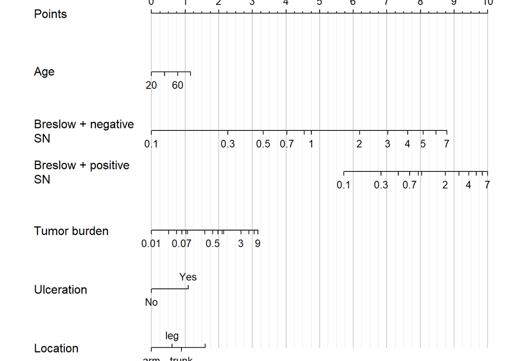

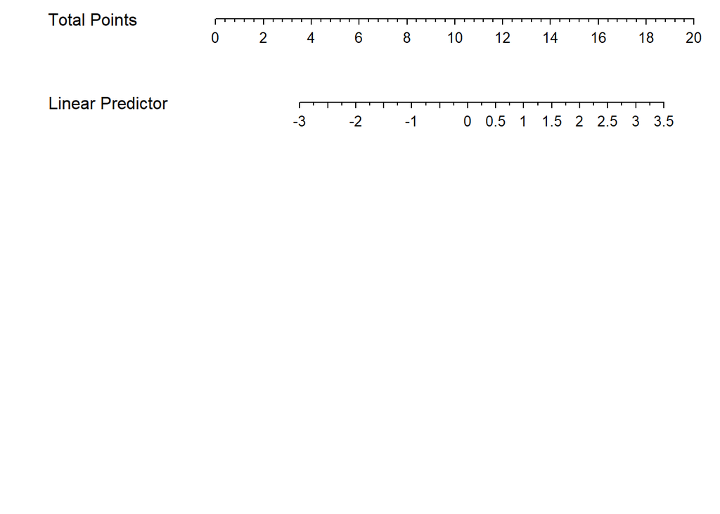

```r
# Limits of Age, Breslow, Rdamcrit
Age.class <- seq(20, 80, 20)
Breslow.class <- c(seq(0.1, 0.9, 0.2), 1:7)
Rdamcrit.class <- c(seq(1, 10, 2)/100, seq(1, 10, 2)/10, seq(1, 10, 2))

# initial nomogram
nom.0 <- nomogram(f.mi.BS.Rec.5,maxscale=10,
                Breslow=Breslow.class, Rdamcrit=Rdamcrit.class, Age.SN=Age.class)

# baseline hazard of recurrence
f.Rec.basehaz <- basehaz(f.mi.BS.Rec.5,TRUE)
h0.Rec <- f.Rec.basehaz$hazard[f.Rec.basehaz$time==max(f.Rec.basehaz$time[f.Rec.basehaz$time<=horizon])]

# lp range Recurrence
rc.Rec <- (1/attributes(nom.0)$info$sc)
int.Rec <- attributes(nom.0)$info$Intercept
lp.range <- int.Rec+rc.Rec*(0:10)*2

# nomogram
nom <- nomogram(f.mi.BS.Rec.5, maxscale=10,
              Breslow=Breslow.class, Rdamcrit=Rdamcrit.class, Age.SN=Age.class,
              lp=TRUE, fun.at=fun.event(lp=lp.range, h0=h0.Rec))
attributes(nom)$names[attributes(nom)$names=="Age.SN"]<-"Age"
attributes(nom)$names[attributes(nom)$names=="Loc_CAT"]<-"Location"
attributes(nom)$names[attributes(nom)$names=="Rdamcrit"]<-"Tumor burden"
attributes(nom)$names[attributes(nom)$names=="Breslow (SNstatus=Positive)"]<-"Breslow + positive SN"
attributes(nom)$names[attributes(nom)$names=="Breslow (SNstatus=Negative)"]<-"Breslow + negative SN"
par(mar = rep(0, 4))
plot(nom, total.sep.page=TRUE, col.grid=gray(c(0.8, 0.95)))
```

```r
nom.0
```

```
## Points per unit of linear predictor: 2.3417112
## Linear predictor units per point   : 0.42703815
##
##
##  Age.SN Points
##  20     0
##  40     0
##  60     1
##  80     1
##
##
##  Breslow (SNstatus=Negative) Points
##  0.1                         0
##  0.3                         2
##  0.5                         3
##  0.7                         4
##  0.9                         5
##  1.0                         5
##  2.0                         6
##  3.0                         7
##  4.0                         8
##  5.0                         8
##  6.0                         8
##  7.0                         9
##
##
##  Breslow (SNstatus=Positive) Points
##  0.1                          6
##  0.3                          7
##  0.5                          7
##  0.7                          8
##  0.9                          8
##  1.0                          8
##  2.0                          9
##  3.0                          9
##  4.0                          9
##  5.0                         10
##  6.0                         10
##  7.0                         10
##
```

[output cut: 14 more lines]

```
##  5.00     3
##  7.00     3
##  9.00     3
##
##
##  Ulceration Points
##  No         0
##  Yes        1
##
##
##  Loc_CAT     Points
##  arm         0
##  leg         1
##  trunk       1
##  head & neck 2
```

```r
nom
```

```
## Points per unit of linear predictor: 2.3417112
## Linear predictor units per point   : 0.42703815
##
##
##  Age Points
##  20  0
##  40  0
##  60  1
##  80  1
##
##
##  Breslow + negative SN Points
##  0.1                   0
##  0.3                   2
##  0.5                   3
##  0.7                   4
##  0.9                   5
##  1.0                   5
##  2.0                   6
##  3.0                   7
##  4.0                   8
##  5.0                   8
##  6.0                   8
##  7.0                   9
##
##
##  Breslow + positive SN Points
##  0.1                    6
##  0.3                    7
##  0.5                    7
##  0.7                    8
##  0.9                    8
##  1.0                    8
##  2.0                    9
##  3.0                    9
##  4.0                    9
##  5.0                   10
##  6.0                   10
##  7.0                   10
##
```

[output cut: 14 more lines]

```
##  5.00         3
##  7.00         3
##  9.00         3
##
##
##  Ulceration Points
##  No         0
##  Yes        1
##
##
##  Location    Points
##  arm         0
##  leg         1
##  trunk       1
##  head & neck 2
```

# Risk score distribution

```r
# baseline hazard of MSM
f.MSM.basehaz <- basehaz(f.mi.BS.MSM.5,TRUE)
h0.MSM <- f.MSM.basehaz$hazard[f.MSM.basehaz$time==max(f.MSM.basehaz$time[f.MSM.basehaz$time<=horizon])]
lp.MSM <- f.mi.BS.MSM.5$linear

# lp range MSM
rc.MSM <- f.mi.BS.MSM.5$coef[1]*rc.Rec
int.MSM <- f.mi.BS.MSM.5$coef[1]*int.Rec
max.range <- 16
points.range <- 0:max.range
lp.points.Rec.5 <- int.Rec+rc.Rec*points.range
lp.points.MSM.5 <- int.MSM+rc.MSM*points.range

# Recurrence lp scores
Breslow.trunc <- last.imputed.data.set$Breslow
Breslow.trunc[last.imputed.data.set$Breslow<0.1] <- .1
Breslow.trunc[last.imputed.data.set$Breslow>7] <- 7
lp.score.Rec <- predict(f.mi.BS.Rec.5,newdata=data.frame(SNstatus=last.imputed.data.set$SNstatus,
                                                Age.SN=last.imputed.data.set$Age.SN,
                                                Ulceration=last.imputed.data.set$Ulceration,
                                                Loc_CAT=last.imputed.data.set$Loc_CAT,
                                                Breslow=Breslow.trunc,
                                                Rdamcrit=last.imputed.data.set$Rdamcrit))
mean(lp.score.Rec)
```

```
## [1] -0.017408958
```

```r
score.Rec <- round((lp.score.Rec-int.Rec)/rc.Rec,0)
max.breaks <- max.range+1
h.Rec <- hist(score.Rec,plot=FALSE,breaks=0:max.breaks,right=FALSE)

# score table
data.frame(table(score.Rec)/length(score.Rec))
```

```
##    score.Rec          Freq
## 1          4 0.00122819946
## 2          5 0.00221075903
## 3          6 0.01080815524
## 4          7 0.04642593957
## 5          8 0.14517317612
## 6          9 0.17882584132
## 7         10 0.15892901007
## 8         11 0.12110046672
## 9         12 0.12429378531
## 10        13 0.10194055515
## 11        14 0.06828788995
## 12        15 0.03340702530
## 13        16 0.00712355687
## 14        17 0.00024563989
```

# Plot of risk score distribution

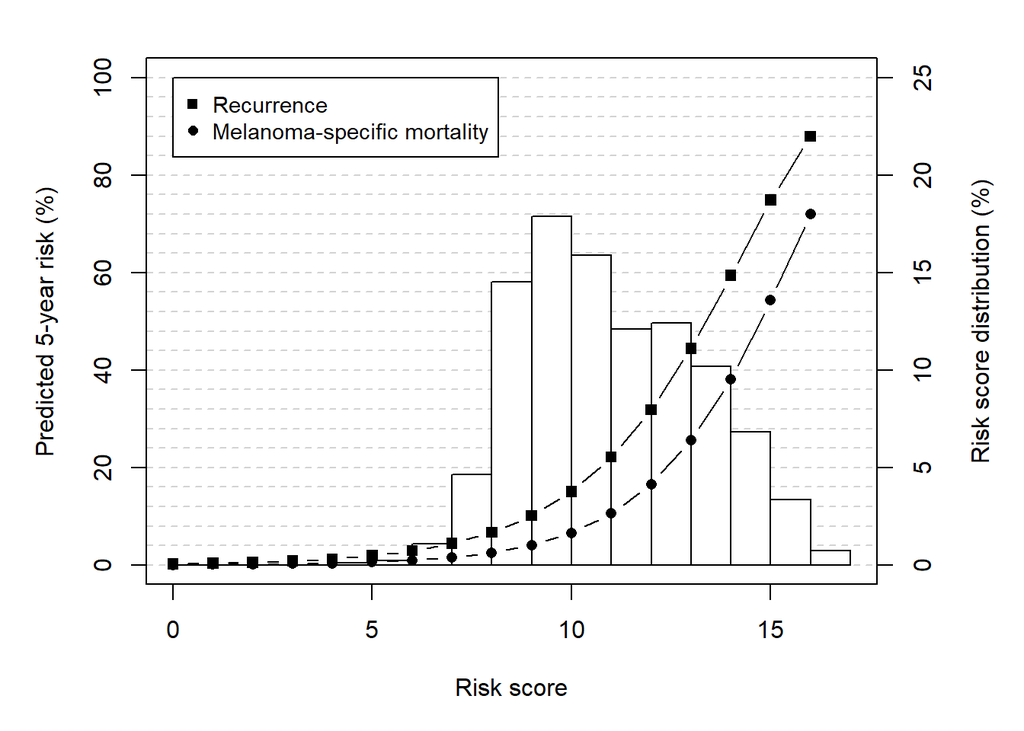

```r
h.plot <- h.Rec
h.plot$density <- 100*h.Rec$density
p.Rec <- fun.event(lp=lp.points.Rec.5, h0=h0.Rec)
p.MSM <- fun.event(lp=lp.points.MSM.5, h0=h0.MSM)
x.lim <- c(0, max.range+1)
y.lim <- c(0, 100)
y.lim.hist <- c(0, 25)
png(file=paste0("Z:/Project Melanoom/PaperMelanoma/Results/Risk.distribution.png"))
par(mar = c(5,5,2,5))
plot(h.plot,freq=FALSE,axes=FALSE, xlab=NA, xlim=x.lim, ylab=NA,ylim=y.lim.hist,main=NA,col='white')
abline(h=(0:30)*1,col="light grey",lty=2)
axis(side = 4)
mtext(side = 4, line = 3, 'Risk score distribution (%)')
par(new = TRUE)
plot(h.plot,freq=FALSE,axes=FALSE, xlab=NA, xlim=x.lim, ylab=NA,ylim=y.lim.hist,main=NA,col="white")
par(new = TRUE)
plot(points.range,p.Rec*100,type="b",lwd=1,xlim=x.lim,ylim=y.lim,pch=15, xlab="Risk score",ylab="Predicted 5-year risk (%)")
points(points.range,p.MSM*100,type="b",lwd=1,xlim=x.lim,ylim=y.lim,pch=16)
legend(x=0,y=100,legend=c("Recurrence","Melanoma-specific mortality"),pch=c(15,16),cex=.9,bg='white')
grDevices::dev.off()
```

```r
# reset margins
par(mar = c(5,5,2,5))

# table of risk distribution
cbind(points.range, round(p.Rec*100, 1), round(p.MSM*100, 1))[c(1, 9, 10, 12, 13),]
```

```
##      points.range
## [1,]            0  0.2  0.1
## [2,]            8  6.7  2.6
## [3,]            9 10.1  4.1
## [4,]           11 22.2 10.6
## [5,]           12 31.9 16.6
```

```r
# save for Rshiny app
coef.Rec <- stats::coef(f.mi.BS.Rec.5)
center.Rec <- f.mi.BS.Rec.5$center
save(h0.Rec, h0.MSM, coef.Rec, c.Breslow, center.Rec, MSM.cal.fact,
     file=paste0('Z:/Project Melanoom/PaperMelanoma/Results/h0.Rec.MSM.Rdata'), compress=TRUE)
load(file=paste0('Z:/Project Melanoom/PaperMelanoma/Results/h0.Rec.MSM.Rdata'))
```

# Test if model is correct

### Check calibration

Intercept of recurrence should be the same as when setting covariates to ‘zero’ values minus the center

```r
int.Rec
```

```
## [1] -4.5005254
```

```r
20*f.mi.BS.Rec.5$coef["Age.SN"]+
  (log(0.1)-c.Breslow)*f.mi.BS.Rec.5$coef["Breslow"]+
  log(0.01)*f.mi.BS.Rec.5$coef["Rdamcrit"]-
  f.mi.BS.Rec.5$center
```

```
##     Age.SN
## -4.5005254
```

### Check mean event rates of risk distribution

#### Recurrence

```r
sum(h.Rec$density*fun.event(lp=lp.points.Rec.5, h0=h0.Rec))
```

```
## [1] 0.23805679
```

```r
# equal to the 5-year survival probability, e.g. kaplan-meier at 5 years, i.e. survfit at 5 years:
SF<-survfit(S.Rec.5~1,data=sel.data)
100*(1-SF$surv[SF$time==max(SF$time[SF$time<=horizon])])
```

```
## [1] 24.544486
```

```r
# average probability of recurrence
mean(fun.event(lp=lp.score.Rec, h0=h0.Rec))
```

```
## [1] 0.23777786
```

#### MSM

```r
sum(h.Rec$density*fun.event(lp=lp.points.MSM.5, h0=h0.MSM))
```

```
## [1] 0.1314428
```

```r
# equal to the 5-year survival probability, e.g. kaplan-meier at 5 years, i.e. survfit at 5 years:
SF<-survfit(S.MSM.5~1,data=sel.data)
100*(1-SF$surv[SF$time==max(SF$time[SF$time<=horizon])])
```

```
## [1] 13.503982
```

```r
# average probability of MSM
mean(fun.event(lp=lp.MSM, h0=h0.MSM))
```

```
## [1] 0.13607372
```

# Check if predictions of new and old model align for negative SN patients

## New model

```r
lp.negative <- predict(f.mi.BS.Rec.5,
                       newdata=last.imputed.data.set[last.imputed.data.set$SNstatus=="Negative",],
                       type="lp")
new.negativeSN.tool <- 1-exp(-h0.Rec*exp(lp.negative))
```

## Old model with new data

```r
rscript.negative <- function(breslow, ulceration, location) {
  S0 <- 0.85837329
  lp <- 0.79351989*log(breslow) +
    0.61912477*I(ulceration == 1) +
    0.29594843*I(location == 1) +
    0.42802046*I(location == 2) +
    0.86053044*I(location == 3) - 0.98860941
  S <- 100 - 100*S0^exp(lp)
  return(S)
}
old.negativeSN.tool <- rscript.negative(breslow=last.imputed.data.set[last.imputed.data.set$SNstatus=="Negative", "Breslow"],
        ulceration=as.numeric(last.imputed.data.set[last.imputed.data.set$SNstatus=="Negative", "Ulceration"])-1,
        location=as.numeric(last.imputed.data.set[last.imputed.data.set$SNstatus=="Negative", "Loc_CAT"])-1)
```

## Compare

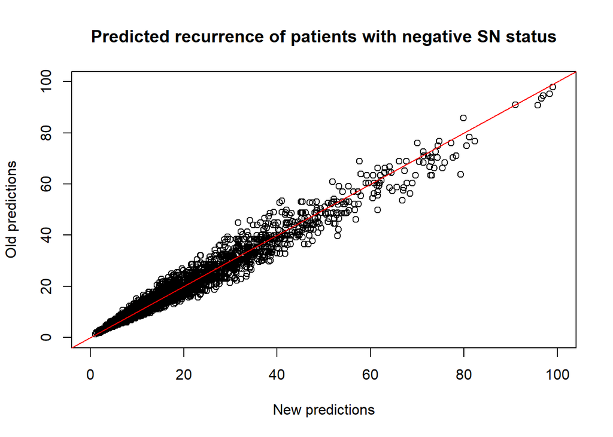

```r
plot(x=new.negativeSN.tool*100, y=old.negativeSN.tool,
     xlim=c(0, 100), ylim=c(0, 100),
     xlab="New predictions", ylab="Old predictions",
     main="Predicted recurrence of patients with negative SN status")
abline(a=0, b=1, col="red")
```

## Refitted old model new data

```r
refitted.old.negative <- rms::cph(S.Rec.5 ~ log(Breslow)+Ulceration+Loc_CAT,
                     data=last.imputed.data.set,
                     y=TRUE, x=TRUE,
                     subset=last.imputed.data.set$SNstatus=="Negative")
refitted.old.negative
```

```
## Cox Proportional Hazards Model
##
##  rms::cph(formula = S.Rec.5 ~ log(Breslow) + Ulceration + Loc_CAT,
##      data = last.imputed.data.set, subset = last.imputed.data.set$SNstatus ==
##          "Negative", x = TRUE, y = TRUE)
##
##                         Model Tests     Discrimination
##                                                Indexes
##  Obs      3182    LR chi2    319.17     R2       0.108
##  Events    448    d.f.            5    R2(5,3182)0.094
##  Center 1.0157    Pr(> chi2) 0.0000     R2(5,448)0.504
##                   Score chi2 359.70     Dxy      0.481
##                   Pr(> chi2) 0.0000
##
##                      Coef   S.E.   Wald Z Pr(>|Z|)
##  Breslow             0.8924 0.0634 14.08  <0.0001
##  Ulceration=Yes      0.5196 0.1038  5.01  <0.0001
##  Loc_CAT=leg         0.2852 0.1585  1.80  0.0720
##  Loc_CAT=trunk       0.4458 0.1525  2.92  0.0035
##  Loc_CAT=head & neck 0.7991 0.1956  4.08  <0.0001
##
```

```r
f.Rec.basehaz.neg <- basehaz(refitted.old.negative,TRUE)
h0.neg <- f.Rec.basehaz.neg$hazard[f.Rec.basehaz.neg$time==max(f.Rec.basehaz.neg$time[f.Rec.basehaz.neg$time<=horizon])]
refit.old.negativeSN.tool <- fun.event(predict(refitted.old.negative),  h0.neg)
```

## Compare

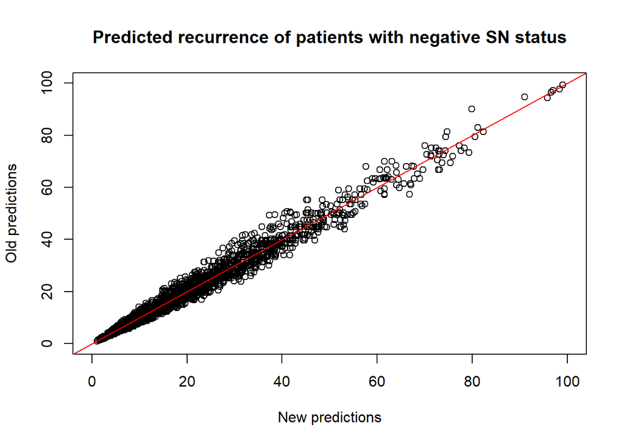

```r
plot(x=new.negativeSN.tool*100, y=refit.old.negativeSN.tool*100,
     xlim=c(0, 100), ylim=c(0, 100),
     xlab="New predictions", ylab="Old predictions",
     main="Predicted recurrence of patients with negative SN status")
abline(a=0, b=1, col="red")
```

## Check mean recurrence probabilities

```r
SF<-survfit(S.Rec.5[last.imputed.data.set$SNstatus=="Negative"]~1)
100*(1-SF$surv[SF$time==max(SF$time[SF$time<=horizon])])
```

```
## [1] 17.98794
```

```r
mean(new.negativeSN.tool)
```

```
## [1] 0.17460511
```

```r
mean(refit.old.negativeSN.tool)
```

```
## [1] 0.17408587
```

```r
mean(old.negativeSN.tool)
```

```
## [1] 17.4444
```

# Check if predictions of new and old model align for positive SN patients

## New model

```r
lp.positive <- predict(f.mi.BS.Rec.5,
                       newdata=last.imputed.data.set[last.imputed.data.set$SNstatus=="Positive",],
                       type="lp")
new.positiveSN.tool <- 1-exp(-h0.Rec*exp(lp.positive))
```

## Old model with new data

```r
rscript.positive <- function(age, ulceration, tumor_burden, breslow) {
  S0 <- 0.51762362
  lp <- 0.56109945 * log(age) +
    0.23383770 * log(tumor_burden) +
    0.35489235 * log(breslow) +
    0.36562098 * I(ulceration == 1) - 2.709225
  S <- 100 - 100 * S0^exp(lp)
  return(S)
}
old.positiveSN.tool <- rscript.positive(age=last.imputed.data.set[last.imputed.data.set$SNstatus=="Positive", "Age.SN"],
                                        ulceration=as.numeric(last.imputed.data.set[last.imputed.data.set$SNstatus=="Positive", "Ulceration"])-1,
                                        breslow=last.imputed.data.set[last.imputed.data.set$SNstatus=="Positive", "Breslow"],
                                        tumor_burden=as.numeric(last.imputed.data.set[last.imputed.data.set$SNstatus=="Positive", "Rdamcrit"]))
```

## Compare

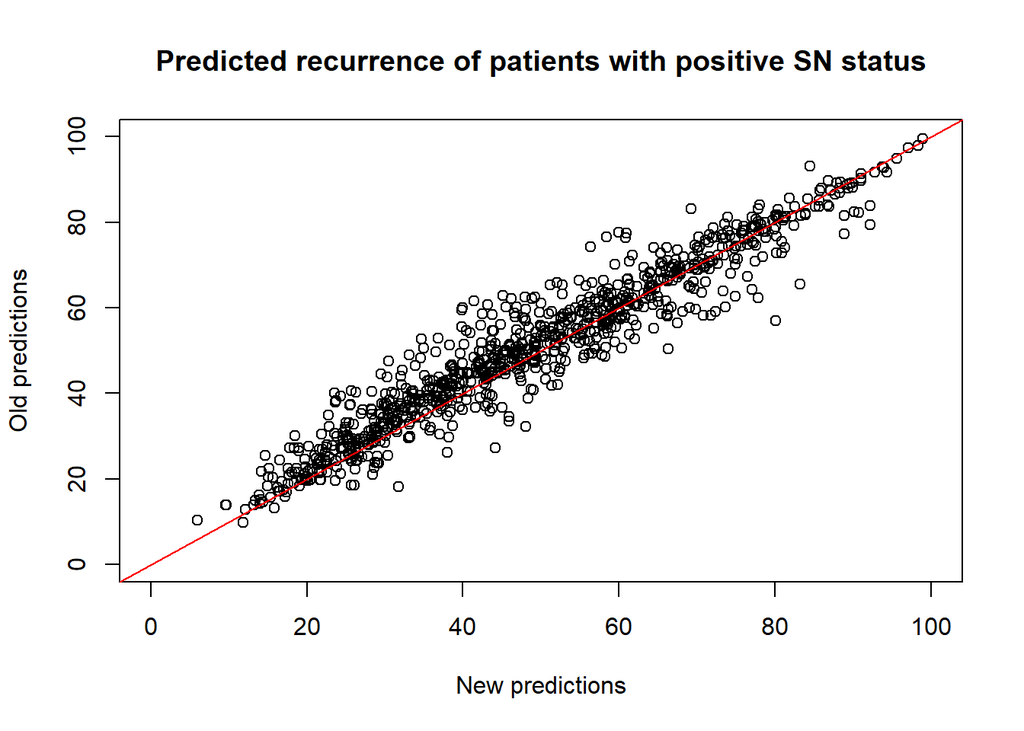

```r
plot(x=new.positiveSN.tool*100, y=old.positiveSN.tool,
     xlim=c(0, 100), ylim=c(0, 100),
     xlab="New predictions", ylab="Old predictions",
     main="Predicted recurrence of patients with positive SN status")
abline(a=0, b=1, col="red")
```

## Refitted old model new data

```r
refitted.old.positive <- rms::cph(S.Rec.5 ~ log(Breslow)+Ulceration+Loc_CAT,
                      data=last.imputed.data.set,
                      y=TRUE, x=TRUE,
                      subset=last.imputed.data.set$SNstatus=="Positive")
refitted.old.positive
```

```
## Cox Proportional Hazards Model
##
##  rms::cph(formula = S.Rec.5 ~ log(Breslow) + Ulceration + Loc_CAT,
##      data = last.imputed.data.set, subset = last.imputed.data.set$SNstatus ==
##          "Positive", x = TRUE, y = TRUE)
##
##                        Model Tests    Discrimination
##                                              Indexes
##  Obs      889    LR chi2     90.43    R2       0.097
##  Events   344    d.f.            5    R2(5,889)0.092
##  Center 1.052    Pr(> chi2) 0.0000    R2(5,344)0.220
##                  Score chi2  90.17    Dxy      0.291
##                  Pr(> chi2) 0.0000
##
##                      Coef   S.E.   Wald Z Pr(>|Z|)
##  Breslow             0.5506 0.0807 6.82   <0.0001
##  Ulceration=Yes      0.4183 0.1156 3.62   0.0003
##  Loc_CAT=leg         0.1561 0.2415 0.65   0.5181
##  Loc_CAT=trunk       0.2943 0.2244 1.31   0.1897
##  Loc_CAT=head & neck 0.4910 0.2873 1.71   0.0874
##
```

```r
f.Rec.basehaz.pos <- basehaz(refitted.old.positive,TRUE)
h0.pos <- f.Rec.basehaz.pos$hazard[f.Rec.basehaz.pos$time==max(f.Rec.basehaz.pos$time[f.Rec.basehaz.pos$time<=horizon])]
refit.old.positiveSN.tool <- fun.event(predict(refitted.old.positive),  h0.pos)
```

## Compare

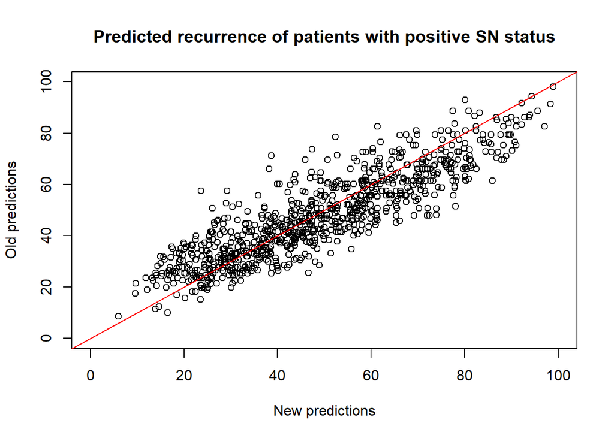

```r
plot(x=new.positiveSN.tool*100, y=refit.old.positiveSN.tool*100,
     xlim=c(0, 100), ylim=c(0, 100),
     xlab="New predictions", ylab="Old predictions",
     main="Predicted recurrence of patients with positive SN status")
abline(a=0, b=1, col="red")
```

## Check mean recurrence probabilities

```r
SF<-survfit(S.Rec.5[last.imputed.data.set$SNstatus=="Positive"]~1)
100*(1-SF$surv[SF$time==max(SF$time[SF$time<=horizon])])
```

```
## [1] 48.691234
```

```r
mean(new.positiveSN.tool)
```

```
## [1] 0.48763344
```

```r
mean(refit.old.positiveSN.tool)
```

```
## [1] 0.47868275
```

```r
mean(old.positiveSN.tool)
```

```
## [1] 50.62421
```

#### Example to check probabilities with app

```r
patient.nr <- 115 # 395 and 396 = Negative, 397 and 398 = Positive, 30 = Head & neck, 115 has large Breslow
print(data.to.be.imputed[patient.nr, c("SNstatus", "Age.SN", "Ulceration", "Loc_CAT", "Breslow", "Rdamcrit")])
```

```
##     SNstatus Age.SN Ulceration Loc_CAT Breslow Rdamcrit
## 115 Negative     42         No   trunk       7        1
```

```r
# calculate linear predictor
lp.score.Rec.true <- predict(f.mi.BS.Rec.5)[patient.nr]
lp.score.Rec.try <- predict(f.mi.BS.Rec.5, newdata=data.frame(SNstatus=data.to.be.imputed[patient.nr,"SNstatus"],
                                                            Age.SN=data.to.be.imputed[patient.nr,"Age.SN"],
                                                            Ulceration=data.to.be.imputed[patient.nr,"Ulceration"],
                                                            Loc_CAT=data.to.be.imputed[patient.nr,"Loc_CAT"],
                                                            Breslow=data.to.be.imputed[patient.nr,"Breslow"],
                                                            Rdamcrit=data.to.be.imputed[patient.nr,"Rdamcrit"]),
                                                            type="lp")
p.Rec.example <- fun.event(lp=lp.score.Rec.try, h0=h0.Rec)
p.MSM.example <- fun.event(lp=lp.score.Rec.try, h0=h0.MSM)

# manual calculation
lp.score.Rec.manual <- coef.Rec["SNstatus=Positive"]*(as.numeric(data.to.be.imputed[patient.nr,"SNstatus"])-1)+
              coef.Rec["Age.SN"]*data.to.be.imputed[patient.nr,"Age.SN"]+
              coef.Rec["Ulceration=Yes"]*(as.numeric(data.to.be.imputed[patient.nr,"Ulceration"])-1)+
              coef.Rec["Loc_CAT=leg"]*as.numeric(data.to.be.imputed[patient.nr,"Loc_CAT"]=="leg")+
              coef.Rec["Loc_CAT=trunk"]*as.numeric(data.to.be.imputed[patient.nr,"Loc_CAT"]=="trunk")+
              coef.Rec["Loc_CAT=head & neck"]*as.numeric(data.to.be.imputed[patient.nr,"Loc_CAT"]=="head & neck")+
              coef.Rec["Breslow"]*(log(data.to.be.imputed[patient.nr,"Breslow"])-c.Breslow)+
              coef.Rec["Rdamcrit"]*log(data.to.be.imputed[patient.nr,"Rdamcrit"])+
              coef.Rec["SNstatus=Positive * Breslow"]*(log(data.to.be.imputed[patient.nr,"Breslow"])-c.Breslow)*(as.numeric(data.to.be.imputed[patient.nr,"SNstatus"])-1)

# lp check
lp.score.Rec.true
```

```
##       115
## 0.7266784
```

```r
lp.score.Rec.try
```

```
##         1
## 0.7266784
```

```r
lp.score.Rec.manual-center.Rec
```

```
## SNstatus=Positive
##         0.7266784
```

```r
# probability of recurrence with fun.event
fun.event(lp=lp.score.Rec.try, h0=h0.Rec)
```

```
##         1
## 0.3464304
```

```r
# probability of recurrence manually
1-exp(-h0.Rec*exp(lp.score.Rec.manual-center.Rec))
```

```
## SNstatus=Positive
##         0.3464304
```

```r
# check calculation of lp of MSM
lp.score.MSM.true <- predict(f.mi.BS.MSM.5)[patient.nr]
lp.score.MSM.true
```

```
##        115
## 0.82900216
```

```r
lp.MSM.try <- MSM.cal.fact*(lp.score.Rec.manual-center.Rec)
lp.MSM.try
```

```
##      lp.BS
## 0.82900216
```

```r
# probability of MSM with fun.event
fun.event(lp=lp.MSM.try, h0=h0.MSM)
```

```
##      lp.BS
## 0.18458755
```

```r
# probability of MSM manually
1-exp(-h0.MSM*exp(MSM.cal.fact*(lp.score.Rec.manual-center.Rec)))
```

```
##      lp.BS
## 0.18458755
```

### Histogram for negative SN status patients

```r
Breslow.trunc.neg <- last.imputed.data.set[last.imputed.data.set$SNstatus=="Negative", "Breslow"]
Breslow.trunc.neg[last.imputed.data.set[last.imputed.data.set$SNstatus=="Negative", "Breslow"]<0.1] <- .1
Breslow.trunc.neg[last.imputed.data.set[last.imputed.data.set$SNstatus=="Negative", "Breslow"]>7] <- 7
lp.score.Rec.negative <- predict(f.mi.BS.Rec.5,newdata=data.frame(SNstatus=last.imputed.data.set[last.imputed.data.set$SNstatus=="Negative", "SNstatus"],
                                                       Age.SN=last.imputed.data.set[last.imputed.data.set$SNstatus=="Negative", "Age.SN"],
                                                       Ulceration=last.imputed.data.set[last.imputed.data.set$SNstatus=="Negative", "Ulceration"],
                                                       Loc_CAT=last.imputed.data.set[last.imputed.data.set$SNstatus=="Negative", "Loc_CAT"],
                                                       Breslow=Breslow.trunc.neg,
                                                       Rdamcrit=last.imputed.data.set[last.imputed.data.set$SNstatus=="Negative", "Rdamcrit"]))
mean(lp.score.Rec.negative)
```

```
## [1] -0.32933459
```

```r
# OK to use int.Rec and rc.Rec based on all patients?
score.Rec.neg <- round((lp.score.Rec.negative-int.Rec)/rc.Rec,0)
h.Rec.neg <- hist(score.Rec.neg,plot=FALSE,breaks=0:max.breaks,right=FALSE)
h.plot.neg <- h.Rec.neg
h.plot.neg$density <- 100*h.Rec.neg$density
```

### Histogram for positive SN status patients

```r
Breslow.trunc.pos <- last.imputed.data.set[last.imputed.data.set$SNstatus=="Positive", "Breslow"]
Breslow.trunc.pos[last.imputed.data.set[last.imputed.data.set$SNstatus=="Positive", "Breslow"]<0.1] <- .1
Breslow.trunc.pos[last.imputed.data.set[last.imputed.data.set$SNstatus=="Positive", "Breslow"]>7] <- 7
lp.score.Rec.positive <- predict(f.mi.BS.Rec.5,newdata=data.frame(SNstatus=last.imputed.data.set[last.imputed.data.set$SNstatus=="Positive", "SNstatus"],
                                                                Age.SN=last.imputed.data.set[last.imputed.data.set$SNstatus=="Positive", "Age.SN"],
                                                                Ulceration=last.imputed.data.set[last.imputed.data.set$SNstatus=="Positive", "Ulceration"],
                                                                Loc_CAT=last.imputed.data.set[last.imputed.data.set$SNstatus=="Positive", "Loc_CAT"],
                                                                Breslow=Breslow.trunc.pos,
                                                                Rdamcrit=last.imputed.data.set[last.imputed.data.set$SNstatus=="Positive", "Rdamcrit"]))
mean(lp.score.Rec.positive)
```

```
## [1] 1.0990673
```

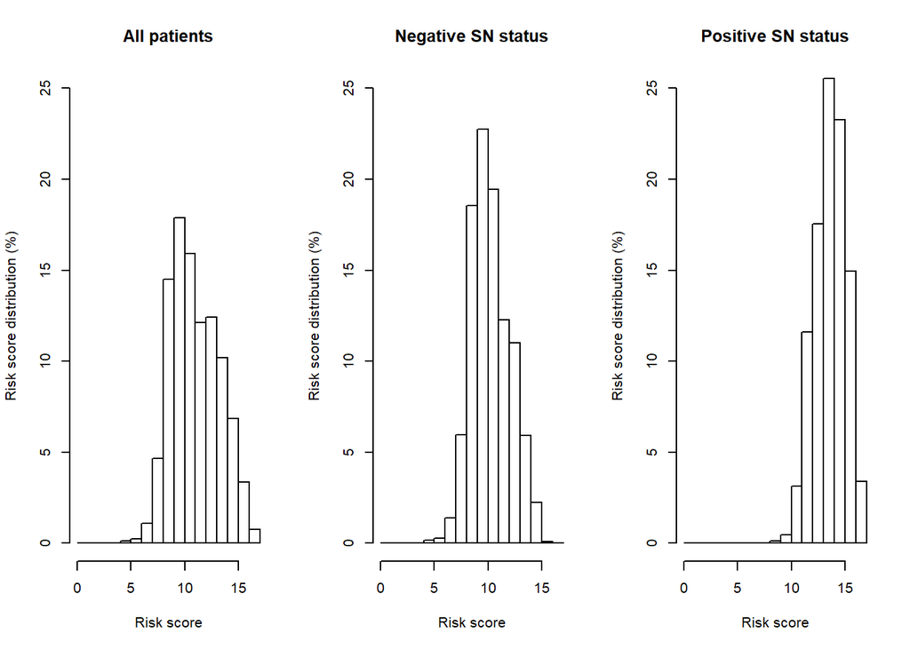

```r
# OK to use int.Rec and rc.Rec based on all patients?
score.Rec.pos <- round((lp.score.Rec.positive-int.Rec)/rc.Rec,0)
h.Rec.pos <- hist(score.Rec.pos,plot=FALSE,breaks=0:max.breaks,right=FALSE)
h.plot.pos <- h.Rec.pos
h.plot.pos$density <- 100*h.Rec.pos$density

par(mfrow=c(1, 3))
plot(h.plot,freq=FALSE,axes=TRUE, xlab="Risk score", xlim=x.lim,ylim=y.lim.hist,
     ylab="Risk score distribution (%)", main="All patients",col="white")
plot(h.plot.neg,freq=FALSE,axes=TRUE, xlab="Risk score", xlim=x.lim,
     ylab="Risk score distribution (%)",ylim=y.lim.hist,main="Negative SN status",col="white")
plot(h.plot.pos,freq=FALSE,axes=TRUE, xlab="Risk score", xlim=x.lim,
     ylab="Risk score distribution (%)",ylim=y.lim.hist,main="Positive SN status",col="white")
```

### Test proportional hazards assumption

```r
test.prop<-survival::cox.zph(f.mi.full.Rec.5$fits[[1]])
test.prop
```

```
##                             chisq df       p
## SNstatus                  1.33901  1 0.24721
## Sex                       0.02644  1 0.87083
## Age.SN                    0.35808  1 0.54957
## Ulceration                3.38893  1 0.06564
## Loc_CAT                  14.46665  3 0.00233
## Histology                 2.32883  3 0.50702
## log(Breslow)              3.02353  1 0.08206
## multiple.fields           2.07388  1 0.14984
## Tot_SNs_neg               0.14725  1 0.70117
## Tot_SNs_pos               0.75326  1 0.38545
## log(Rdamcrit)             0.48634  1 0.48556
## Dewar                     1.93672  4 0.74740
## SNstatus:Sex              0.09535  1 0.75748
## SNstatus:Age.SN           0.96661  1 0.32553
## SNstatus:Ulceration       1.57704  1 0.20919
## SNstatus:Loc_CAT          7.55585  3 0.05614
## SNstatus:Histology        1.70996  3 0.63472
## SNstatus:log(Breslow)     1.19319  1 0.27469
## SNstatus:multiple.fields  2.75535  1 0.09693
## GLOBAL                   45.59412 30 0.03396
```

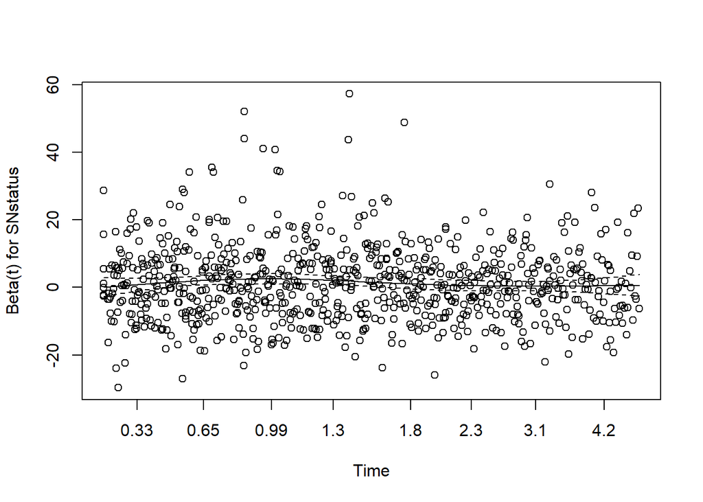

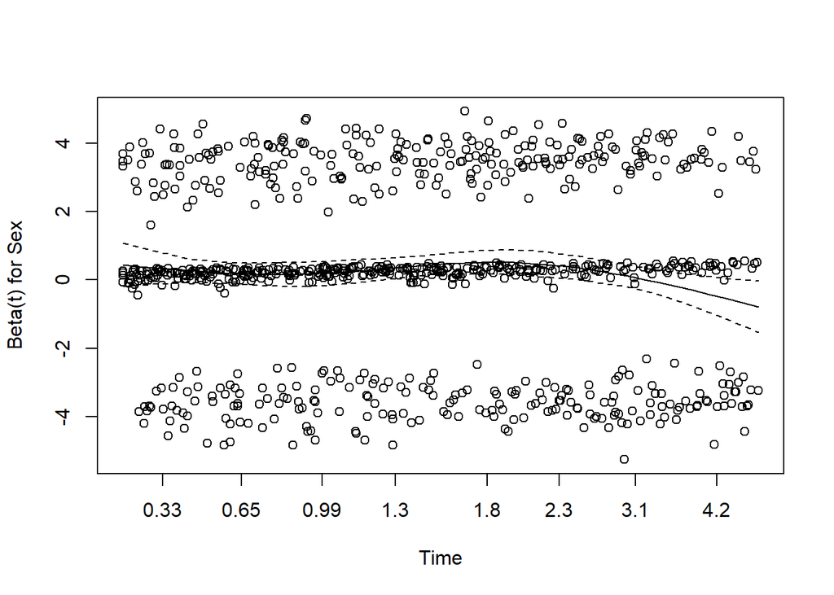

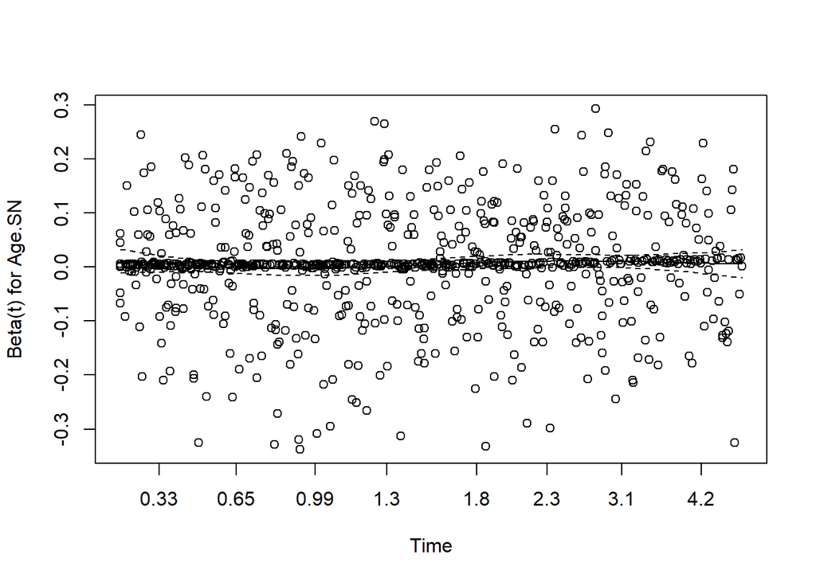

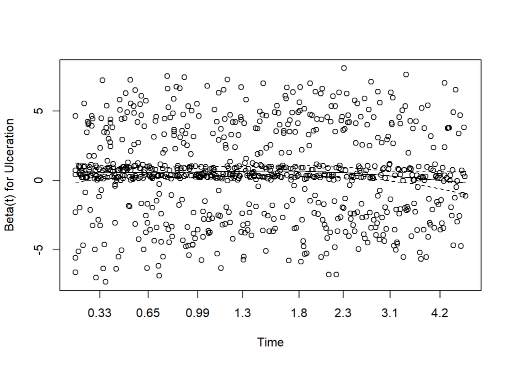

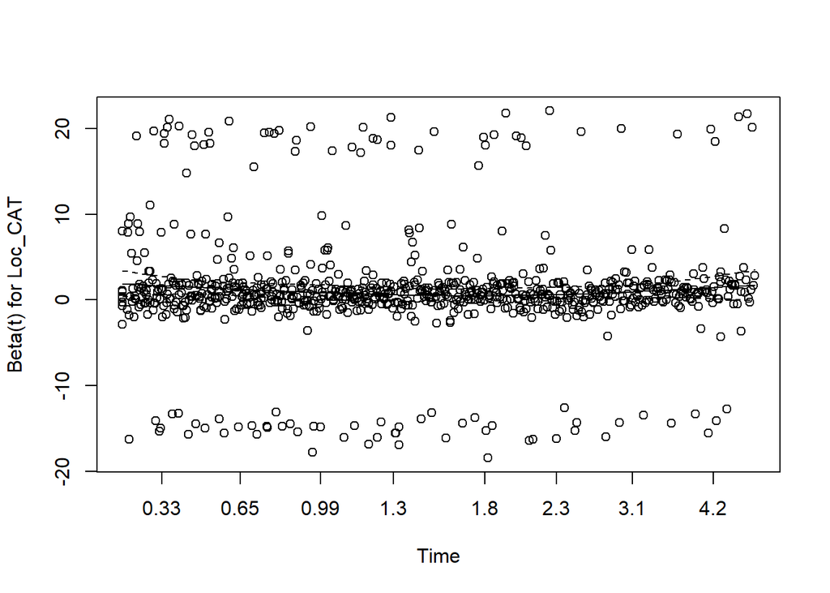

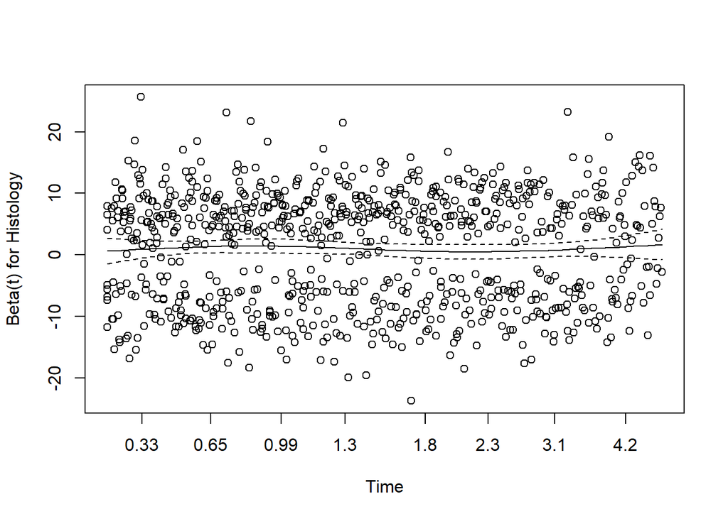

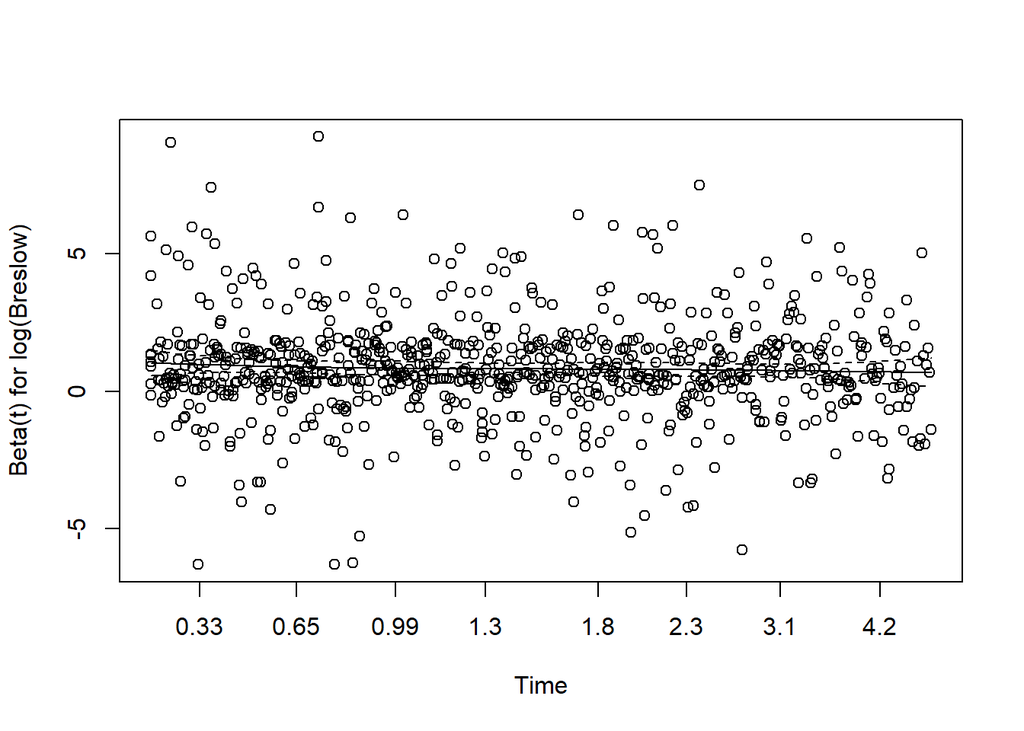

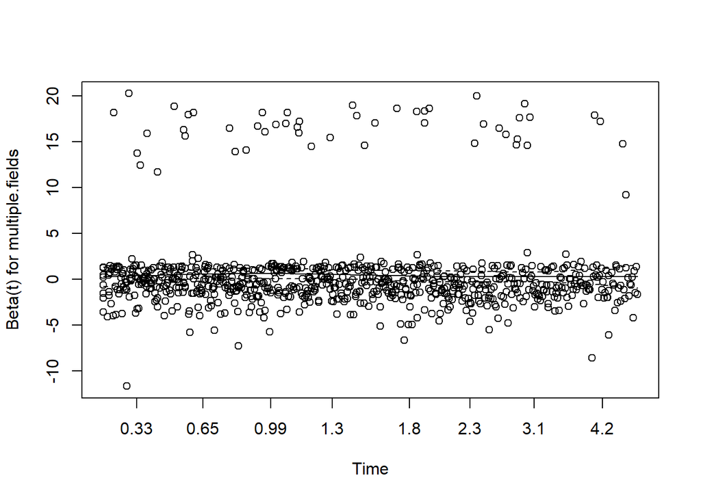

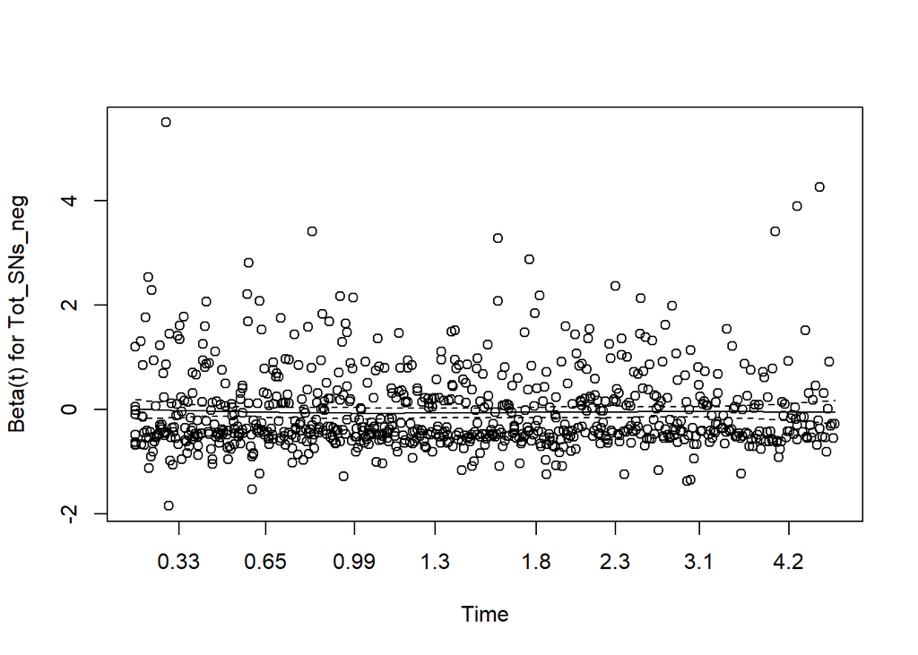

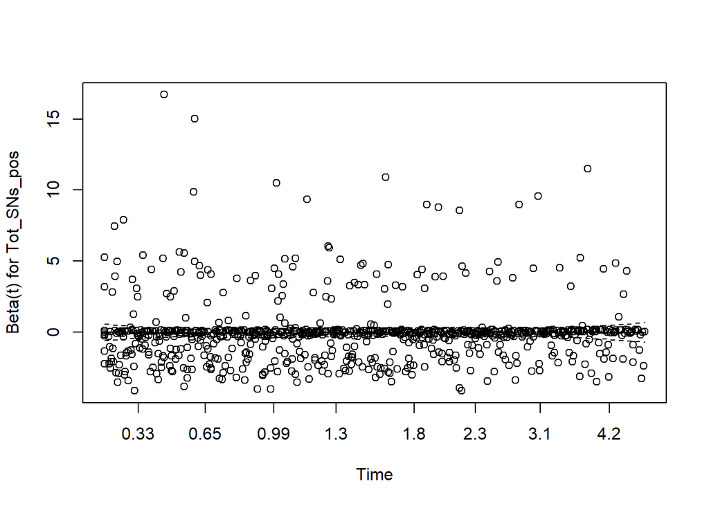

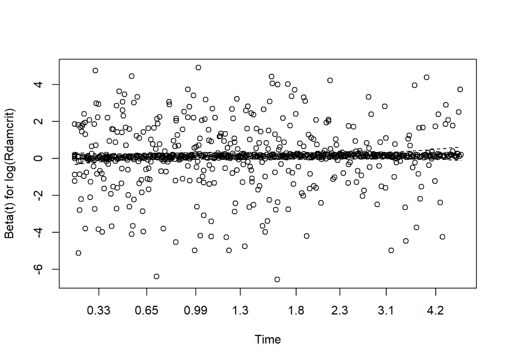

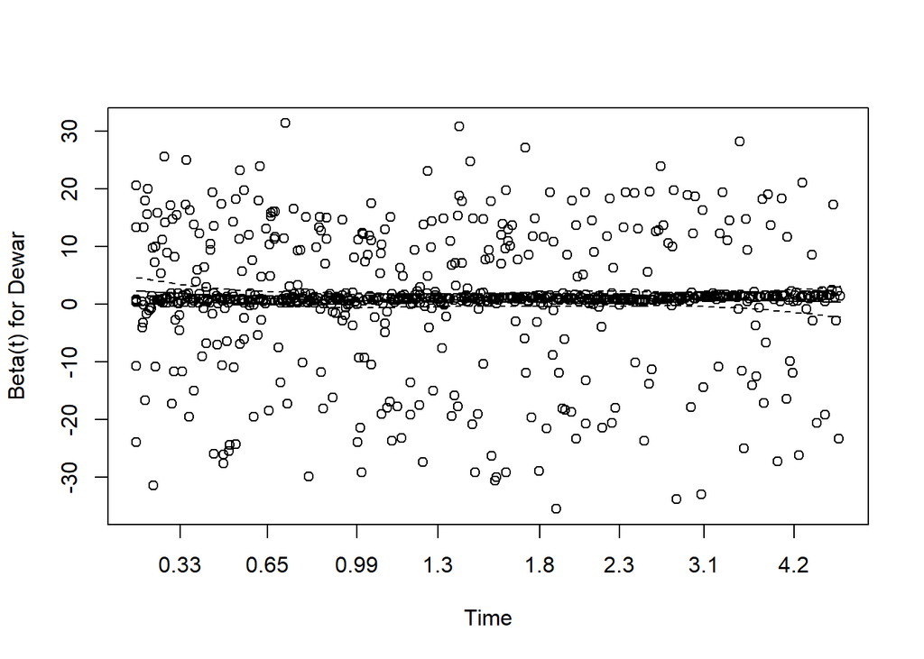

[7 more figures not shown]

```r
plot(test.prop)
```